# Floor Area and Regional Differences in New Home Prices

STA302 Part 2: reproducible analysis and diagnostic appendix

Project Group 62

16 November 2026 - rubric revision 2

# 1 Research question and scope

Among new detached, non-condominium homes sold in the United States in 2025, how is sale price associated with finished floor area, and how does this association vary across the nine Census divisions after adjustment for housing characteristics? A single national adjustment for house size may obscure differences between regional markets. Buyers comparing new houses and analysts describing regional markets need to distinguish a size association from differences in the mix of rooms, amenities and land. Regression makes those adjustments simultaneously; a comparison of regional means or a simple area-price correlation cannot. This study describes associations, not appraisal accuracy or the causal return to enlarging a house.

Sirmans et al. (2006) found geographic and specification-related variation in estimated floor-area coefficients across housing studies. Gyourko and Saiz (2006) documented regional construction-cost differences; those mechanisms cannot be identified with this model. Zietz et al. (2008) found that housing-characteristic associations vary across price quantiles. Our conditional-mean analysis of transformed price addresses a different estimand. Regression provides adjusted comparisons; simple regional averages would also reflect different housing mixes.

The focal inferential tools are division-specific coefficients, confidence intervals and the partial F-test of all eight area-by-division interaction coefficients. Model selection and remaining assumption violations make inference exploratory. Conventional intervals and partial F-tests rely on assumptions that remain imperfect here; their nominal coverage and p-values are not guaranteed. The separate internal audit is not part of this course analysis.

# 2 Data, provenance and cleaning

The Census Bureau’s 2025 Survey of Construction (SOC) microdata are an official national survey of sampled permits and canvassed areas without permits. Builders or owners are interviewed during construction. HUD supports collection of housing characteristics. The documented collection process, public codebook and disclosure flags support provenance; they do not remove reporting or sampling error. Price includes land. Public files omit addresses and builder identifiers, and modify extreme prices, floor areas and lot sizes. The Census Bureau warns that disclosure modifications alter relationships. We use the data for aggregate research, preserve attribution and do not attempt re-identification.

This file runs directly from the original CSV and the archived split; no preliminary knit is required. All estimation and model decisions below use training rows. Cleaning counts describe sample eligibility. The archived test set is accessed for evaluation only if `evaluate_test` is enabled after the model is frozen. Existing records assert no prior test modelling; this review confirms the archived evaluation chunk was disabled, but cannot establish the complete history of every earlier inspection.

```r
raw <- read.csv("data/original/soc25.csv")
clean_soc <- function(raw, year) {
  steps <- data.frame(step = character(0), rows_remaining = integer(0))
  add <- function(label, d) {
    steps[nrow(steps) + 1, ] <<- list(label, nrow(d))
    d
  }
  s <- add(sprintf("All %d SOC records", year), raw)
  s <- add("CAT = 1 (house built for sale)", s[s$CAT == 1, ])
  s <- add(sprintf("Sales contract signed in %d", year),
           s[s$SALE >= year * 100 + 1 & s$SALE <= year * 100 + 12, ])
  s <- add("Detached (DET = 1) and not in a condominium project (CON = 2)",
           s[s$DET == 1 & s$CON == 2, ])
  s <- add("Sale price reported (SLPR > 0)", s[s$SLPR > 0, ])
  s <- add("Floor area and lot size reported (SQFS > 0, AREA > 0)",
           s[s$SQFS > 0 & s$AREA > 0, ])
  # valid (reported) codes of the 12 categorical source fields
  valid <- list(STOR = 1:3, BEDR = 2:5, FULB = 1:4, HAFB = 0:2, GAR = 1:4, BASE = 1:4,
                FPLS = 0:2, ASSOC = 1:2, AGER = 1:2, WAL1 = c(1, 2, 4:9), FUEL = 1:5,
                SEWER = 1:3)
  ok <- rep(TRUE, nrow(s))
  for (v in names(valid)) ok <- ok & s[[v]] %in% valid[[v]]
  s <- add("No 'not reported' code in any categorical predictor", s[ok, ])
  list(data = s, steps = steps)
}

cl <- clean_soc(raw, 2025)
cl$steps
```

```
##                                                            step rows_remaining
## 1                                          All 2025 SOC records          25246
## 2                                CAT = 1 (house built for sale)          16849
## 3                                 Sales contract signed in 2025           8901
## 4 Detached (DET = 1) and not in a condominium project (CON = 2)           7382
## 5                                Sale price reported (SLPR > 0)           7062
## 6         Floor area and lot size reported (SQFS > 0, AREA > 0)           6315
## 7           No 'not reported' code in any categorical predictor           6185
```

```r
stopifnot(nrow(cl$data) == 6185)
```

```r
recode <- function(x, map) unname(map[as.character(x)])
ym <- function(x) (x %/% 100) * 12 + x %% 100            # YYYYMM -> month count

division_levels <- c("SouthAtlantic", "NewEngland", "MidAtlantic", "ENCentral", "WNCentral",
                     "ESCentral", "WSCentral", "Mountain", "Pacific")
factor_levels <- list(
  division = division_levels,
  stories = c("1", "2", "3plus"),
  bedrooms = c("2orless", "3", "4", "5plus"),
  fullbath = c("1orless", "2", "3", "4plus"),
  halfbath = c("0", "1", "2plus"),
  garage = c("1car", "2car", "3plus", "other"),
  foundation = c("basement", "crawl", "slab", "other"),
  fireplace = c("0", "1", "2plus"),
  hoa = c("no", "yes"),
  age_restricted = c("no", "yes"),
  wall = c("brick", "wood", "stucco", "vinyl", "stone", "fibercement", "other"),
  heat_fuel = c("electric", "gas", "propane", "other"),
  sewer = c("public", "septic"),
  stage = c("completed", "under_constr", "not_started"))

construct_soc <- function(s) {
  sale_m <- ym(s$SALE)
  strt_m <- ifelse(s$STRT > 0, ym(s$STRT), 1e9)
  comp_m <- ifelse(s$COMP > 0, ym(s$COMP), 1e9)
  data.frame(
    id = s$ID,
    price_k = s$SLPR / 1000,
    sqft100 = s$SQFS / 100,
    lot_k = s$AREA / 1000,
    division = recode(s$DIV, c("1" = "NewEngland", "2" = "MidAtlantic", "3" = "ENCentral",
                               "4" = "WNCentral", "5" = "SouthAtlantic", "6" = "ESCentral",
                               "7" = "WSCentral", "8" = "Mountain", "9" = "Pacific")),
    stories = recode(s$STOR, c("1" = "1", "2" = "2", "3" = "3plus")),
    bedrooms = recode(s$BEDR, c("2" = "2orless", "3" = "3", "4" = "4", "5" = "5plus")),
    fullbath = recode(s$FULB, c("1" = "1orless", "2" = "2", "3" = "3", "4" = "4plus")),
    halfbath = recode(s$HAFB, c("0" = "0", "1" = "1", "2" = "2plus")),
    garage = recode(s$GAR, c("1" = "1car", "2" = "2car", "3" = "3plus", "4" = "other")),
    foundation = recode(s$BASE, c("1" = "basement", "2" = "crawl", "3" = "slab", "4" = "other")),
    fireplace = recode(s$FPLS, c("0" = "0", "1" = "1", "2" = "2plus")),
    hoa = recode(s$ASSOC, c("1" = "yes", "2" = "no")),
    age_restricted = recode(s$AGER, c("1" = "yes", "2" = "no")),
    wall = recode(s$WAL1, c("1" = "wood", "2" = "brick", "4" = "stucco", "5" = "vinyl",
                            "6" = "other", "7" = "stone", "8" = "fibercement", "9" = "other")),
    heat_fuel = recode(s$FUEL, c("1" = "electric", "2" = "gas", "3" = "propane",
                                 "4" = "other", "5" = "other")),
    sewer = recode(s$SEWER, c("1" = "public", "2" = "septic", "3" = "septic")),
    sale_month = s$SALE %% 100,
    stage = ifelse(sale_m < strt_m, "not_started",
                   ifelse(sale_m < comp_m, "under_constr", "completed")),
    slpr_flag = s$SLPR_F,
    sqft_flag = s$SQFS_F, lot_flag = s$AREA_F,
    weight = s$WEIGHT,
    stringsAsFactors = FALSE)
}

as_model_factors <- function(d) {
  for (v in names(factor_levels)) d[[v]] <- factor(d[[v]], levels = factor_levels[[v]])
  d
}

soc <- construct_soc(cl$data)
stopifnot(!anyNA(soc), !anyDuplicated(soc$id))
dim(soc)
```

```
## [1] 6185   23
```

```r
split_ids <- read.csv("data/split_ids.csv")
stopifnot(!anyDuplicated(split_ids$id), !anyDuplicated(soc$id),
          setequal(split_ids$id,soc$id), all(split_ids$split %in% c("train","test")))
soc$split <- split_ids$split[match(soc$id,split_ids$id)]
stopifnot(sum(soc$split=="train")==4330, sum(soc$split=="test")==1855)
write.csv(soc,"data/cleaned/soc_clean_review.csv",row.names=FALSE)
train <- as_model_factors(soc[soc$split=="train",])
rm(soc)
train$log_price <- log(train$price_k)
train$log_sqft <- log(train$sqft100*100)
train$log_sqft_c <- train$log_sqft-mean(train$log_sqft)
n <- nrow(train)
write.csv(cl$steps,"results/cleaning_flow.csv",row.names=FALSE)
knitr::kable(cl$steps,caption="Table 1. Sequential eligibility and complete-case counts.")
```

Table 1. Sequential eligibility and complete-case counts.

| step | rows_remaining |
| --- | --- |
| All 2025 SOC records | 25246 |
| CAT = 1 (house built for sale) | 16849 |
| Sales contract signed in 2025 | 8901 |
| Detached (DET = 1) and not in a condominium project (CON = 2) | 7382 |
| Sale price reported (SLPR > 0) | 7062 |
| Floor area and lot size reported (SQFS > 0, AREA > 0) | 6315 |
| No ‘not reported’ code in any categorical predictor | 6185 |

The complete-case loss is 16.2% of the 7,382 eligible homes. The split is fixed at 4,330 training and 1,855 test homes. Complete-case analysis may select better-reported homes; results are unweighted sample associations, not design-based national estimates. The 17 initial predictor concepts comprise three numerical variables (area, lot size, sale month) and 14 categorical variables. Factor coding and the original category pooling are retained above.

```r
skew <- function(x) { z <- x - mean(x); mean(z^3) / mean(z^2)^1.5 }
exkurt <- function(x) { z <- x - mean(x); mean(z^4) / mean(z^2)^2 - 3 }

num_vars <- c(price_k = "Response: sale price ($1000s)",
              sqft100 = "Finished floor area (100 sq ft)",
              lot_k = "Lot size (1000 sq ft)",
              sale_month = "Month contract signed (1-12)")
num_tab <- data.frame(
  variable = names(num_vars), description = unname(num_vars),
  mean = sapply(names(num_vars), function(v) mean(train[[v]])),
  sd = sapply(names(num_vars), function(v) sd(train[[v]])),
  min = sapply(names(num_vars), function(v) min(train[[v]])),
  median = sapply(names(num_vars), function(v) median(train[[v]])),
  max = sapply(names(num_vars), function(v) max(train[[v]])),
  skewness = sapply(names(num_vars), function(v) skew(train[[v]])),
  missing = sapply(names(num_vars), function(v) sum(is.na(train[[v]]))),
  row.names = NULL)
knitr::kable(num_tab, digits = 2, caption = "Numerical variables (training set)")
```

Numerical variables (training set)

| variable | description | mean | sd | min | median | max | skewness | missing |
| --- | --- | --- | --- | --- | --- | --- | --- | --- |
| price_k | Response: sale price ($1000s) | 526.97 | 307.41 | 209.90 | 433.0 | 3300.00 | 3.04 | 0 |
| sqft100 | Finished floor area (100 sq ft) | 25.45 | 9.95 | 7.11 | 23.0 | 85.07 | 1.67 | 0 |
| lot_k | Lot size (1000 sq ft) | 14.06 | 16.56 | 2.00 | 8.7 | 87.12 | 3.10 | 0 |
| sale_month | Month contract signed (1-12) | 6.28 | 3.42 | 1.00 | 6.0 | 12.00 | 0.09 | 0 |

```r
cat_vars <- names(factor_levels)
cat_tab <- data.frame(
  variable = cat_vars,
  levels = sapply(cat_vars, function(v) nlevels(train[[v]])),
  counts = sapply(cat_vars, function(v) {
    tb <- table(train[[v]]); paste(names(tb), tb, sep = ": ", collapse = "; ")
  }),
  missing = sapply(cat_vars, function(v) sum(is.na(train[[v]]))),
  row.names = NULL)
knitr::kable(cat_tab, caption = "Categorical variables (training set; first level = reference)")
```

Categorical variables (training set; first level = reference)

| variable | levels | counts | missing |
| --- | --- | --- | --- |
| division | 9 | SouthAtlantic: 1308; NewEngland: 39; MidAtlantic: 119; ENCentral: 510; WNCentral: 313; ESCentral: 344; WSCentral: 850; Mountain: 473; Pacific: 374 | 0 |
| stories | 3 | 1: 2120; 2: 2116; 3plus: 94 | 0 |
| bedrooms | 4 | 2orless: 154; 3: 1780; 4: 1777; 5plus: 619 | 0 |
| fullbath | 4 | 1orless: 46; 2: 2664; 3: 1203; 4plus: 417 | 0 |
| halfbath | 3 | 0: 2373; 1: 1897; 2plus: 60 | 0 |
| garage | 4 | 1car: 158; 2car: 3124; 3plus: 919; other: 129 | 0 |
| foundation | 4 | basement: 992; crawl: 403; slab: 2926; other: 9 | 0 |
| fireplace | 3 | 0: 2781; 1: 1383; 2plus: 166 | 0 |
| hoa | 2 | no: 1109; yes: 3221 | 0 |
| age_restricted | 2 | no: 4216; yes: 114 | 0 |
| wall | 7 | brick: 897; wood: 169; stucco: 906; vinyl: 1362; stone: 56; fibercement: 926; other: 14 | 0 |
| heat_fuel | 4 | electric: 2147; gas: 2083; propane: 52; other: 48 | 0 |
| sewer | 2 | public: 3893; septic: 437 | 0 |
| stage | 3 | completed: 2452; under_constr: 1344; not_started: 534 | 0 |

```r
skew <- function(x) { z <- x - mean(x); mean(z^3) / mean(z^2)^1.5 }
exkurt <- function(x) { z <- x - mean(x); mean(z^4) / mean(z^2)^2 - 3 }
r2 <- function(m) summary(m)$r.squared
adjr2 <- function(m) summary(m)$adj.r.squared
# Conventional nested F-test for terms that differ between two models
pf_test <- function(full, red) {
  a <- anova(red, full)
  c(F = a$F[2], df = a$Df[2], p = a[2, "Pr(>F)"], dR2 = r2(full) - r2(red))
}
fp <- function(p) formatC(p, format = "e", digits = 2)       # p-values for tables
div_slopes <- function(m, x, V = vcov(m), df = df.residual(m)) {
  b <- coef(m)
  t(sapply(division_levels, function(g) {
    L <- setNames(numeric(length(b)), names(b)); L[x] <- 1
    if (g != "SouthAtlantic") L[paste0(x, ":division", g)] <- 1
    est <- sum(L * b); se <- sqrt(drop(t(L) %*% V %*% L)); tq <- qt(0.975, df)
    c(est = est, se = se, lower = est - tq * se, upper = est + tq * se,
      p = 2 * pt(-abs(est / se), df))
  }))
}
fig_out <- function(name, width, height, draw) {
  png(file.path("figures", name), width = width, height = height, units = "in", res = 200)
  draw(); invisible(dev.off()); draw()
}
pt_col <- adjustcolor("#33658a", alpha.f = 0.25); ln_col <- "#d1495b"
```

```r
diagnostic_grid <- function(m,label) {
  mf <- model.frame(m); y <- model.response(mf); e <- resid(m); yh <- fitted(m)
  nv <- names(mf)[-1][vapply(mf[-1],is.numeric,logical(1))]
  par(mfrow=c(2,ceiling((4+length(nv))/2)),mar=c(4.2,4.2,2.5,1),las=1)
  plot(yh,y,pch=16,cex=.3,col=pt_col,xlab="Fitted response",ylab="Observed response",main=label)
  abline(0,1,lty=2); lines(lowess(yh,y),col=ln_col,lwd=2)
  plot(yh,e,pch=16,cex=.3,col=pt_col,xlab="Fitted response",ylab="Residual",main="Residuals vs fitted")
  abline(h=0,lty=2); lines(lowess(yh,e),col=ln_col,lwd=2)
  plot(yh,sqrt(abs(rstandard(m))),pch=16,cex=.3,col=pt_col,xlab="Fitted response",ylab="sqrt(|standardized residual|)",main="Scale-location")
  lines(lowess(yh,sqrt(abs(rstandard(m)))),col=ln_col,lwd=2)
  qqnorm(rstandard(m),pch=16,cex=.3,col=pt_col,main="Normal Q-Q");qqline(rstandard(m),col=ln_col)
  nv <- names(mf)[-1][vapply(mf[-1],is.numeric,logical(1))]
  for(v in nv) {
    plot(mf[[v]],e,pch=16,cex=.3,col=pt_col,xlab=v,ylab="Residual",main=paste("Residuals:",v))
    abline(h=0,lty=2);lines(lowess(mf[[v]],e),col=ln_col,lwd=2)
  }
}
predictor_grid <- function(m,label) {
 mf<-model.frame(m); xx<-mf[-1]; xx<-xx[vapply(xx,is.numeric,logical(1))]
 if(ncol(xx)<2)return(invisible(NULL))
 pairs(xx,pch=16,cex=.25,col=pt_col,main=label,
       lower.panel=function(x,y,...){points(x,y,...);lines(lowess(x,y),col=ln_col,lwd=2)})
}
category_grid <- function(m,label) {
 mf<-model.frame(m); cats<-names(mf)[vapply(mf,is.factor,logical(1))]
 par(mfrow=c(ceiling(length(cats)/3),3),mar=c(5,4,2,1),cex.axis=.7)
 for(v in cats) {boxplot(resid(m)~mf[[v]],outline=TRUE,cex=.25,las=2,
     xlab="",ylab="Residual",main=v,col="#e0e9ee");abline(h=0,lty=2,col=ln_col)}
}
```

# 3 Preliminary model and diagnostic order

First inspect the response-versus-fitted relationship and numerical predictor relationships (the course Conditions 1 and 2), then residual mean patterns, spread, tails and possible dependence. Finally inspect collinearity and influence. These plots provide limited diagnostic evidence; one violation can affect another plot.

```r
ctrl_all <- "lot_k + stories + bedrooms + fullbath + halfbath + garage + foundation + fireplace + hoa + age_restricted + wall + heat_fuel + sewer + stage + sale_month"
f1 <- as.formula(paste("price_k ~ sqft100 * division +", ctrl_all))
m1 <- lm(f1, data = train)
m1_noint <- update(m1, . ~ . - sqft100:division)
m1_noX <- update(m1, . ~ . - sqft100:division - sqft100)
p1_int_F <- pf_test(m1, m1_noint)
p1_int_F
```

```
##            F           df            p          dR2
## 3.727242e+01 8.000000e+00 1.181457e-57 1.998589e-02
```

```r
slopes_p1 <- div_slopes(m1, "sqft100")
```

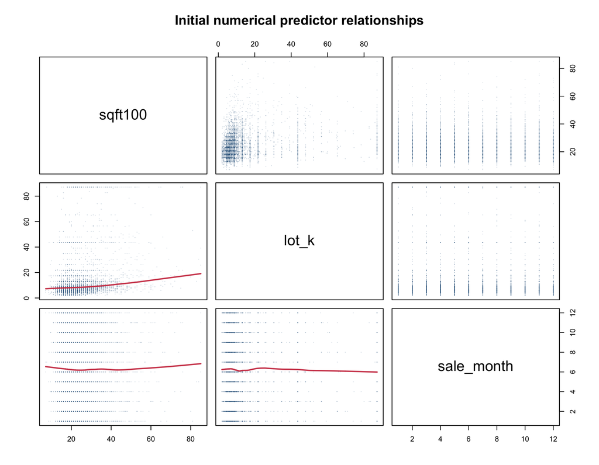

```r
predictor_grid(m1,"Initial numerical predictor relationships")
```

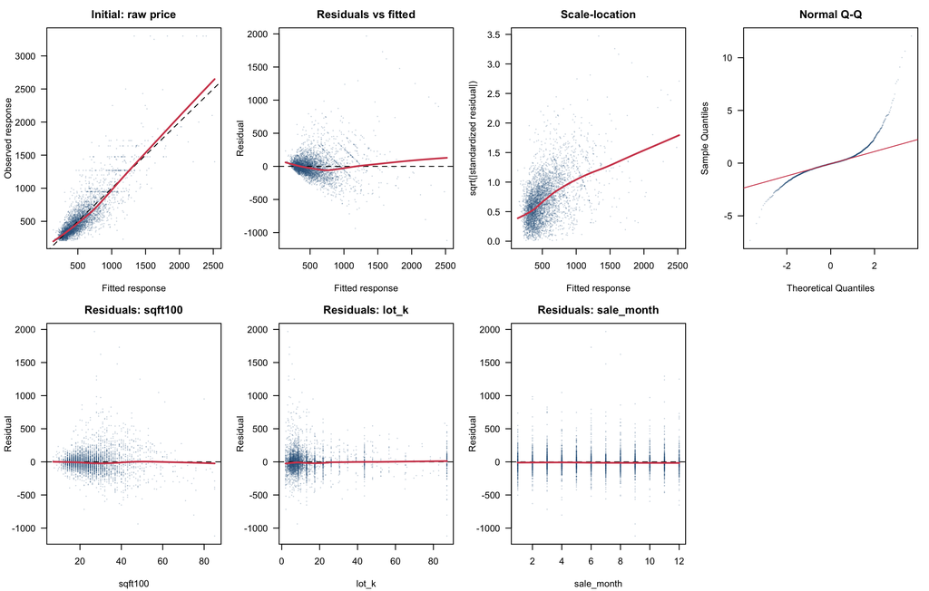

```r
diagnostic_grid(m1,"Initial: raw price")
```

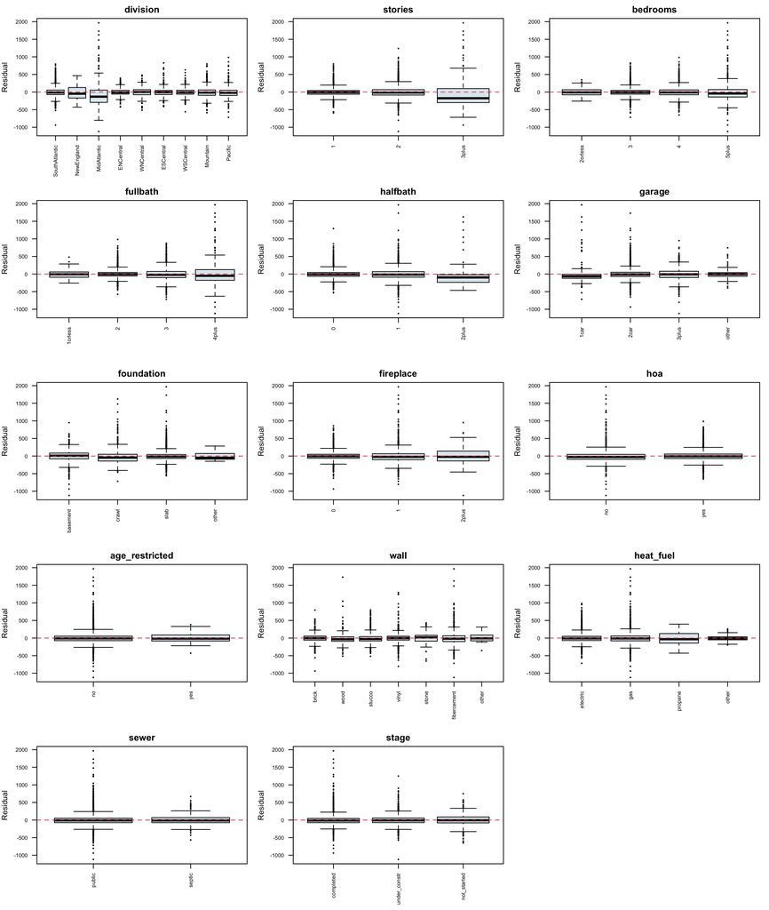

```r
category_grid(m1,"Initial categories")
```

Raw-price residuals show curvature, fanning and heavy tails. The response-fitted plot is broadly increasing; numerical predictor pairs are only a limited screen for the conditional-mean predictor condition. Survey sampling and distinct records do not establish independent errors: builder and subdivision identifiers are unavailable. No residual-order plot can recover those missing clusters.

# 4 Transformations

The first Box-Cox profile uses the original raw-area design. Changing the predictor scale changes that design, so we also profile the response after replacing raw area by log area. We compare raw price, log price and an inverse-square-root response with matched predictor specifications. The latter is `z = -2 * (price_k^(-0.5) - 1)`, where `price_k` is price in thousands of dollars. This transformation is increasing: a positive area coefficient still indicates a positive size-price association. Transformations are chosen from residual evidence, not from the smallest interaction p-value.

```r
# y = TRUE stores the response so that boxcox() does not need to re-fit the model
bc <- boxcox(lm(f1, data = train, y = TRUE), lambda = seq(-1, 0.5, by = 0.001), plotit = FALSE)
lambda_hat <- bc$x[which.max(bc$y)]
lambda_ci <- range(bc$x[bc$y > max(bc$y) - qchisq(0.95, 1) / 2])
# exact maximiser of the same profile log-likelihood
X1 <- model.matrix(m1); y1 <- train$price_k; qr1 <- qr(X1)
bc_ll <- function(l) {
  yt <- if (abs(l) < 1e-12) log(y1) else (y1^l - 1) / l
  -n / 2 * log(sum(qr.resid(qr1, yt)^2)) + (l - 1) * sum(log(y1))
}
lambda_exact <- optimize(bc_ll, c(-1, 0.5), maximum = TRUE, tol = 1e-10)$maximum
c(lambda_grid = lambda_hat, ci_low = lambda_ci[1], ci_high = lambda_ci[2], lambda_exact = lambda_exact)
```

```
##  lambda_grid       ci_low      ci_high lambda_exact
##   -0.4210000   -0.4700000   -0.3720000   -0.4208349
```

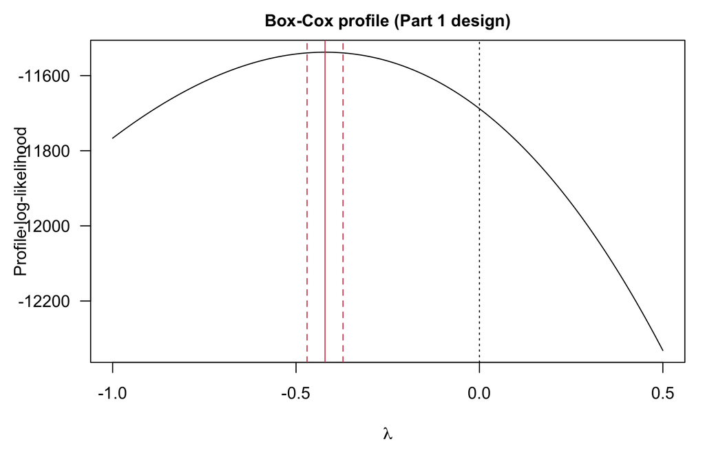

```r
par(mar = c(4.5, 4.5, 2, 1), las = 1)
plot(bc$x, bc$y, type = "l", xlab = expression(lambda), ylab = "Profile log-likelihood",
     main = "Box-Cox profile (Part 1 design)", cex.main = 1)
abline(v = c(lambda_hat, lambda_ci), lty = c(1, 2, 2), col = ln_col)
abline(v = 0, lty = 3)
```

```r
train$bc_m05 <- -2*(train$price_k^(-0.5)-1)
f_loglin <- as.formula(paste("log_price ~ sqft100 * division +",ctrl_all))
f_loglog <- as.formula(paste("log_price ~ log_sqft * division +",ctrl_all))
f_bc05 <- as.formula(paste("bc_m05 ~ sqft100 * division +",ctrl_all))
f_bc_log <- as.formula(paste("bc_m05 ~ log_sqft * division +",ctrl_all))
m_loglin<-lm(f_loglin,data=train);m_loglog<-lm(f_loglog,data=train)
m_bc05<-lm(f_bc05,data=train);m_bc_log<-lm(f_bc_log,data=train)
# Same Box-Cox method, now conditional on the log-area design.
bc_log<-boxcox(lm(as.formula(paste("price_k ~ log_sqft * division +",ctrl_all)),data=train,y=TRUE),
 lambda=seq(-.8,.3,.001),plotit=FALSE)
lambda_log<-bc_log$x[which.max(bc_log$y)]
lambda_log_ci<-range(bc_log$x[bc_log$y>max(bc_log$y)-qchisq(.95,1)/2])
# Descriptive equal-count fifths summarize spread; this is not a hypothesis test.
spread_summary<-function(m){
 rs<-rstandard(m);q<-cut(rank(fitted(m),ties.method="first"),breaks=seq(0,nobs(m),length.out=6),include.lowest=TRUE)
 v<-tapply(abs(rs),q,median)
 c(low=unname(v[1]),high=unname(v[5]),ratio=unname(v[5]/v[1]))
}
candidate_models<-list(raw_price=m1,log_price_raw_area=m_loglin,log_price_log_area=m_loglog,
 inverse_sqrt_raw_area=m_bc05,inverse_sqrt_log_area=m_bc_log)
candidate_metrics<-do.call(rbind,lapply(names(candidate_models),function(nm){
 mm<-candidate_models[[nm]];ss<-spread_summary(mm);rs<-rstandard(mm)
 data.frame(model=nm,response=as.character(formula(mm)[[2]]),coefficients=length(coef(mm)),
 BIC=BIC(mm),R2=r2(mm),std_residual_skew=skew(rs),std_residual_excess_kurtosis=exkurt(rs),
 low_fifth_spread=ss["low"],high_fifth_spread=ss["high"],high_low_spread_ratio=ss["ratio"])
}))
write.csv(candidate_metrics,"results/transformation_comparison.csv",row.names=FALSE)
knitr::kable(candidate_metrics,digits=3,caption="Candidate evidence. BIC/R-squared are comparable only within the same response scale. Spread ratio near 1 describes similar end-fifth spread, not proof of homoscedasticity.")
```

Candidate evidence. BIC/R-squared are comparable only within the same response scale. Spread ratio near 1 describes similar end-fifth spread, not proof of homoscedasticity.

|  | model | response | coefficients | BIC | R2 | std_residual_skew | std_residual_excess_kurtosis | low_fifth_spread | high_fifth_spread | high_low_spread_ratio |
| --- | --- | --- | --- | --- | --- | --- | --- | --- | --- | --- |
| low | raw_price | price_k | 52 | 56927.988 | 0.713 | 2.040 | 18.489 | 0.229 | 1.020 | 4.463 |
| low1 | log_price_raw_area | log_price | 52 | -148.644 | 0.746 | 0.541 | 2.675 | 0.475 | 0.735 | 1.547 |
| low2 | log_price_log_area | log_price | 52 | -351.067 | 0.757 | 0.479 | 2.617 | 0.443 | 0.750 | 1.695 |
| low3 | inverse_sqrt_raw_area | bc_m05 | 52 | -27080.233 | 0.732 | 0.149 | 1.568 | 0.648 | 0.617 | 0.952 |
| low4 | inverse_sqrt_log_area | bc_m05 | 52 | -27426.062 | 0.753 | 0.126 | 1.745 | 0.603 | 0.614 | 1.018 |

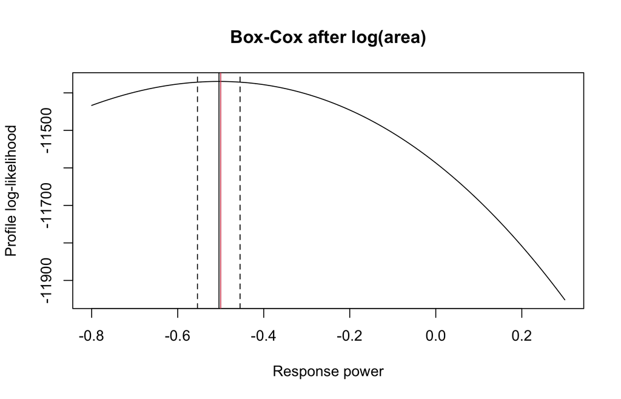

```r
plot(bc_log$x,bc_log$y,type="l",xlab="Response power",ylab="Profile log-likelihood",main="Box-Cox after log(area)")
abline(v=c(lambda_log,lambda_log_ci),lty=c(1,2,2));abline(v=-.5,col=ln_col)
```

```r
for(nm in c("m_loglin","m_loglog","m_bc05","m_bc_log")) {
 diagnostic_grid(get(nm),nm)
 predictor_grid(get(nm),paste(nm,"predictor relationships"))
}
```

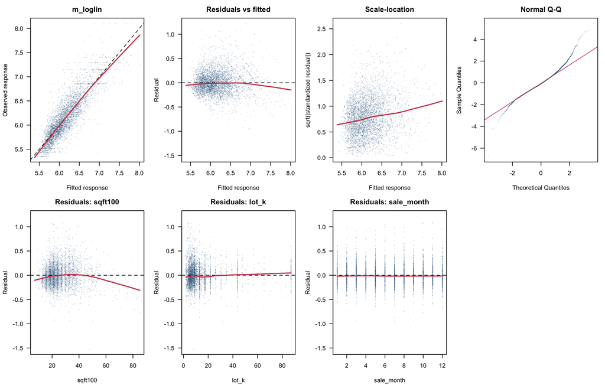

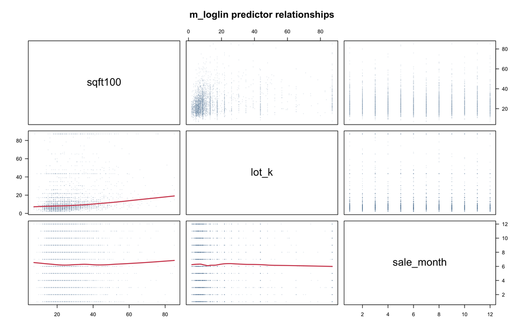

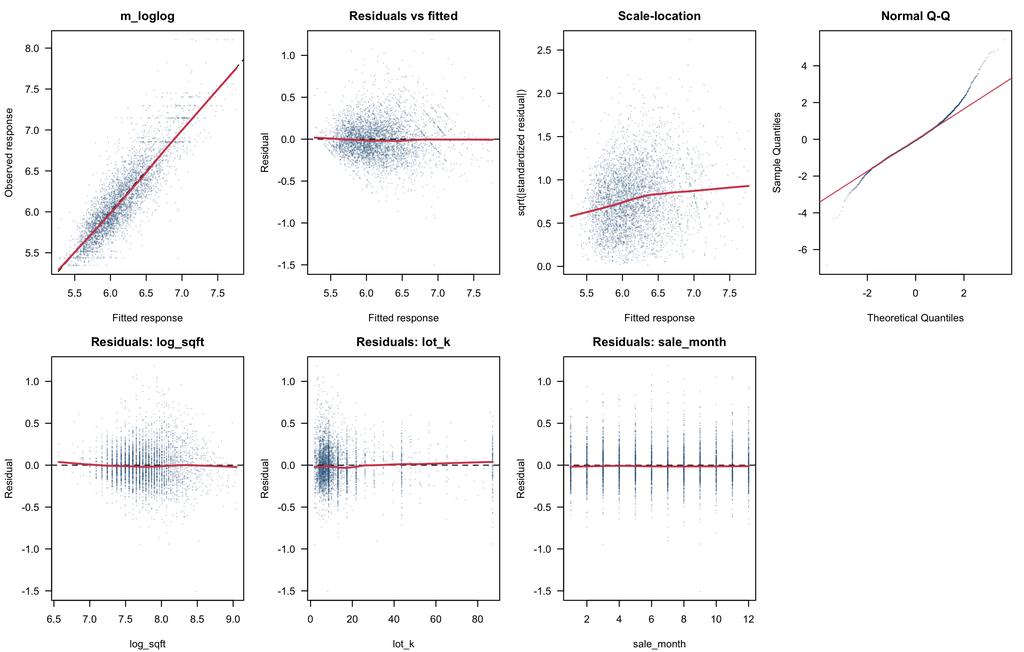

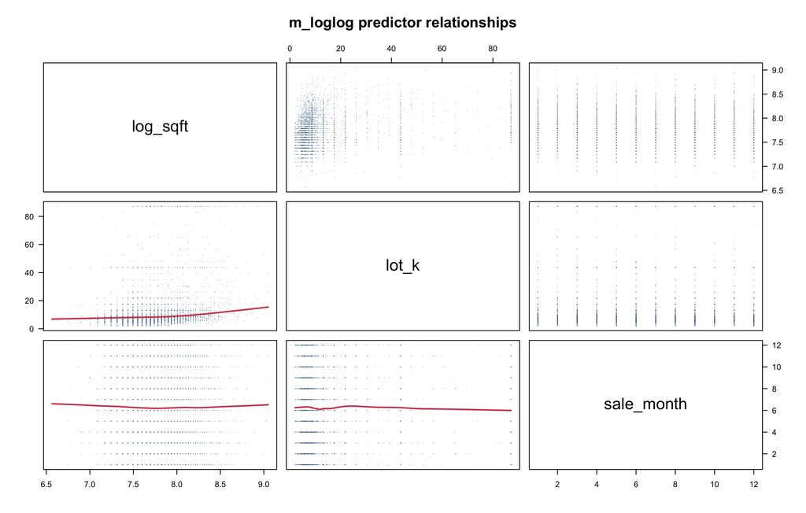

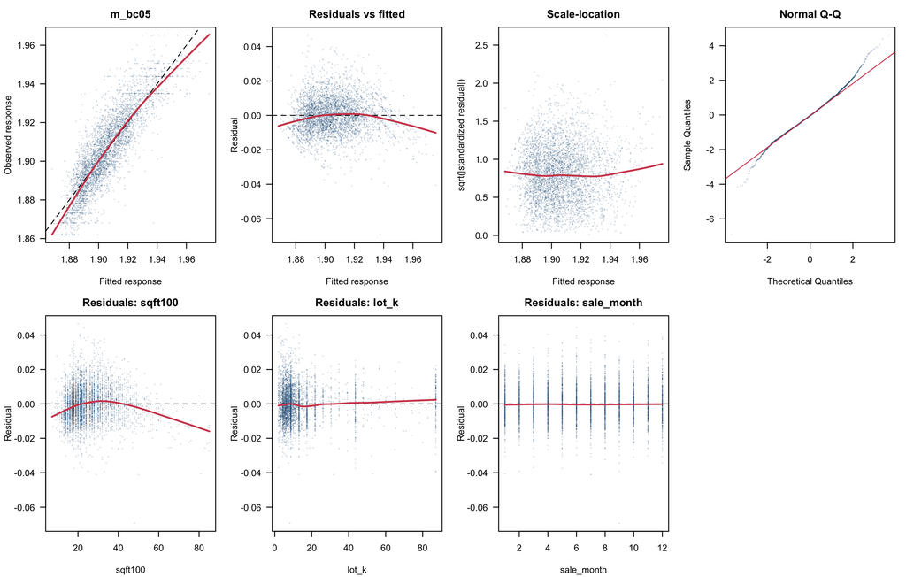

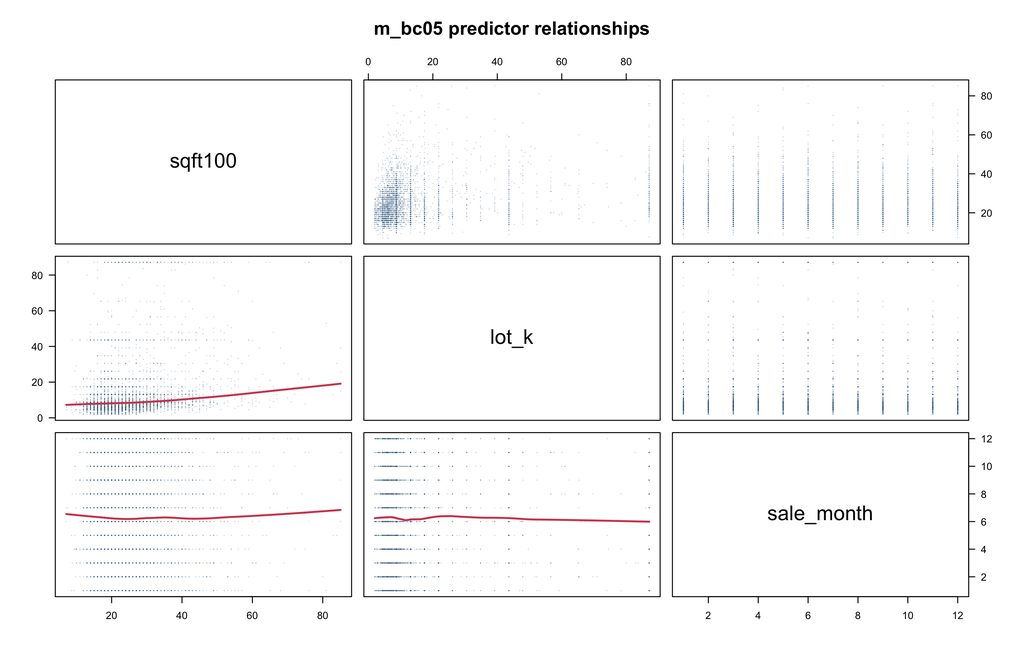

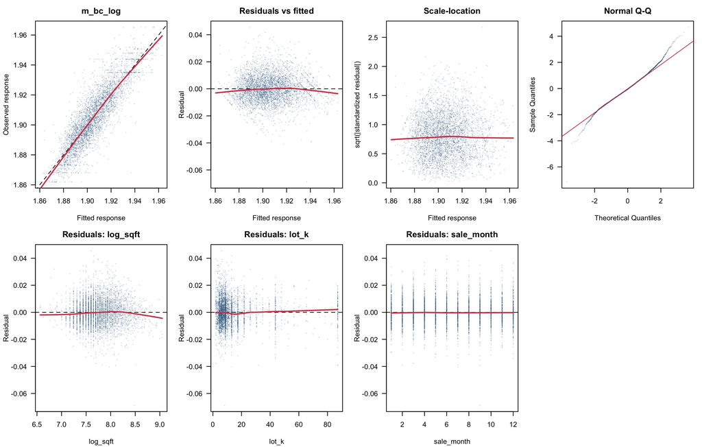

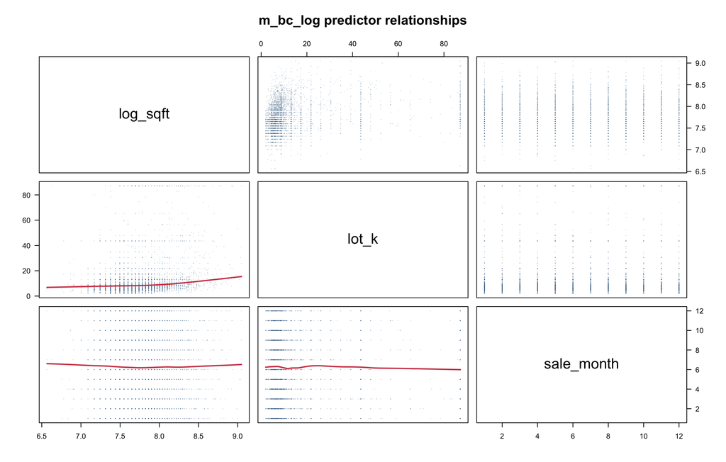

With the original design, the profile estimate is -0.421 (95% profile interval [-0.470, -0.372]). With log area it is -0.504 ([-0.554, -0.455]); -0.5 is now directly supported. The log/log candidate has a high-to-low fitted-fifth residual-spread ratio of 1.69, versus 1.02 for inverse-square-root/log. The latter also reduces standardized-residual skewness and has a flatter mean pattern than its raw-area counterpart. We therefore choose the inverse-square-root response with log area for the primary analysis. The previous log/log specification is retained as a scale-sensitivity comparison, not defended solely because its interpretation is simpler. Q-Q tail deviations remain; these diagnostics improve rather than prove the assumptions. Do not compare BIC or R-squared across different response scales.

# 5 Collinearity and variable selection

We use automated backward BIC for a reproducible, parsimonious search across the optional control groups. A completely manual search would make repeated discretionary testing harder to audit. Practical and ethical constraints remain manual: preserve floor area, division, their interaction, and lot size on substantive grounds; respect hierarchy; retain valid extreme homes rather than remove them to improve significance. BIC uses a different penalty from a 5% partial-F rule. AIC and the full model are sensitivity analyses, not alternative routes to the smallest p-value. Module 9 (slide 48) warns that ordinary F/t p-values after automated selection are no longer valid for confirmatory inference and ordinary intervals can be misleading. The numbers below are exploratory model summaries, not calibrated confirmation of a regional population difference. Choosing a manual search would not by itself remove data-dependent selection uncertainty.

Centering changes the intercept and division main-effect interpretation. It can reduce structural collinearity from the interaction, but does not eliminate genuine relationships among housing features.

```r
# Ordinary VIF = 1/(1-R_j^2) for each encoded design column (Module 7).
column_vif<-function(m,label){
 X<-model.matrix(m);jj<-which(colnames(X)!="(Intercept)")
 vv<-sapply(jj,function(j){a<-lm.fit(X[,-j,drop=FALSE],X[,j]);
 sum((X[,j]-mean(X[,j]))^2)/sum(a$residuals^2)})
 data.frame(parameterization=label,column=colnames(X)[jj],VIF=vv,row.names=NULL)
}
train$log_sqft_c<-train$log_sqft-mean(train$log_sqft)
m_full_centered<-lm(update(f_bc_log,.~.-log_sqft*division+log_sqft_c*division),data=train)
candidate_vif<-rbind(column_vif(m1,"raw_initial"),column_vif(m_bc_log,"chosen_full"),
 column_vif(m_full_centered,"chosen_full_centered"))
write.csv(candidate_vif,"results/candidate_column_VIF.csv",row.names=FALSE)
for(nm in unique(candidate_vif$parameterization)){
 vv<-subset(candidate_vif,parameterization==nm);vv<-vv[order(-vv$VIF),]
 print(knitr::kable(head(vv,10),digits=3,caption=paste("Largest encoded-column VIFs:",nm)))
}
```

```
##
##
## Table: Largest encoded-column VIFs: raw_initial
##
## |   |parameterization |column                    |    VIF|
## |:--|:----------------|:-------------------------|------:|
## |16 |raw_initial      |fullbath2                 | 28.037|
## |17 |raw_initial      |fullbath3                 | 25.855|
## |7  |raw_initial      |divisionWSCentral         | 13.176|
## |18 |raw_initial      |fullbath4plus             | 13.023|
## |49 |raw_initial      |sqft100:divisionWSCentral | 12.297|
## |9  |raw_initial      |divisionPacific           | 11.645|
## |4  |raw_initial      |divisionENCentral         | 11.026|
## |5  |raw_initial      |divisionWNCentral         | 10.960|
## |14 |raw_initial      |bedrooms4                 | 10.618|
## |51 |raw_initial      |sqft100:divisionPacific   | 10.409|
##
##
## Table: Largest encoded-column VIFs: chosen_full
##
## |    |parameterization |column                     |     VIF|
## |:---|:----------------|:--------------------------|-------:|
## |58  |chosen_full      |divisionWSCentral          | 787.014|
## |100 |chosen_full      |log_sqft:divisionWSCentral | 785.642|
## |60  |chosen_full      |divisionPacific            | 719.074|
## |102 |chosen_full      |log_sqft:divisionPacific   | 710.537|
## |55  |chosen_full      |divisionENCentral          | 666.165|
## |97  |chosen_full      |log_sqft:divisionENCentral | 659.624|
## |59  |chosen_full      |divisionMountain           | 603.513|
## |101 |chosen_full      |log_sqft:divisionMountain  | 602.225|
## |56  |chosen_full      |divisionWNCentral          | 577.189|
## |57  |chosen_full      |divisionESCentral          | 575.483|
##
##
## Table: Largest encoded-column VIFs: chosen_full_centered
##
## |    |parameterization     |column        |    VIF|
## |:---|:--------------------|:-------------|------:|
## |109 |chosen_full_centered |fullbath2     | 28.477|
## |110 |chosen_full_centered |fullbath3     | 26.434|
## |111 |chosen_full_centered |fullbath4plus | 13.137|
## |107 |chosen_full_centered |bedrooms4     | 10.995|
## |106 |chosen_full_centered |bedrooms3     |  9.620|
## |108 |chosen_full_centered |bedrooms5plus |  7.284|
## |115 |chosen_full_centered |garage3plus   |  6.892|
## |137 |chosen_full_centered |log_sqft_c    |  6.841|
## |114 |chosen_full_centered |garage2car    |  6.615|
## |126 |chosen_full_centered |wallvinyl     |  3.217|
```

```r
d1 <- drop1(m_bc_log, scope = ~ stories + bedrooms + fullbath + halfbath + garage + foundation +
              fireplace + hoa + age_restricted + wall + heat_fuel + sewer + stage + sale_month + lot_k,
            test = "F")
d1[order(-d1[, "Pr(>F)"]), ]
```

```
## Single term deletions
##
## Model:
## bc_m05 ~ log_sqft * division + lot_k + stories + bedrooms + fullbath +
##     halfbath + garage + foundation + fireplace + hoa + age_restricted +
##     wall + heat_fuel + sewer + stage + sale_month
##                Df Sum of Sq     RSS    AIC F value    Pr(>F)
## sale_month      1 0.0001528 0.40631 -40054  1.6094 0.2046402
## hoa             1 0.0001683 0.40633 -40054  1.7728 0.1831078
## sewer           1 0.0002042 0.40636 -40054  2.1512 0.1425332
## age_restricted  1 0.0003714 0.40653 -40052  3.9116 0.0480178 *
## lot_k           1 0.0008438 0.40700 -40047  8.8876 0.0028872 **
## stage           2 0.0013932 0.40755 -40043  7.3370 0.0006592 ***
## garage          3 0.0030371 0.40920 -40028 10.6632 5.562e-07 ***
## heat_fuel       3 0.0031941 0.40935 -40026 11.2142 2.508e-07 ***
## halfbath        2 0.0038533 0.41001 -40017 20.2931 1.692e-09 ***
## stories         2 0.0039289 0.41009 -40016 20.6910 1.141e-09 ***
## wall            6 0.0054119 0.41157 -40009  9.5005 2.148e-10 ***
## bedrooms        3 0.0066990 0.41286 -39989 23.5197 4.286e-15 ***
## foundation      3 0.0133010 0.41946 -39920 46.6989 < 2.2e-16 ***
## fullbath        3 0.0176524 0.42381 -39876 61.9763 < 2.2e-16 ***
## fireplace       2 0.0182404 0.42440 -39868 96.0613 < 2.2e-16 ***
## <none>                      0.40616 -40054
## ---
## Signif. codes:  0 '***' 0.001 '**' 0.01 '*' 0.05 '.' 0.1 ' ' 1
```

```r
# the research-question terms: interaction, and X + interaction
rbind(interaction = pf_test(m_bc_log, update(m_bc_log, . ~ . - log_sqft:division)),
      area_and_interaction = pf_test(m_bc_log, update(m_bc_log, . ~ . - log_sqft:division - log_sqft)))
```

```
##                              F df             p         dR2
## interaction           16.65027  8  1.548625e-24 0.007699257
## area_and_interaction 154.04011  9 4.882354e-253 0.080133458
```

```r
lower_f <- ~ log_sqft * division + lot_k
sel_aic <- step(m_bc_log, scope = list(lower = lower_f, upper = formula(m_bc_log)),
                direction = "backward", k = 2, trace = 0)
sel_bic <- step(m_bc_log, scope = list(lower = lower_f, upper = formula(m_bc_log)),
                direction = "backward", k = log(n), trace = 0)
sel_aic$anova
```

```
##           Step Df     Deviance Resid. Df Resid. Dev       AIC
## 1              NA           NA      4278  0.4061598 -40053.86
## 2 - sale_month  1 0.0001528022      4279  0.4063126 -40054.23
## 3        - hoa  1 0.0001683987      4280  0.4064810 -40054.43
```

```r
sel_bic$anova
```

```
##               Step Df     Deviance Resid. Df Resid. Dev       AIC
## 1                  NA           NA      4278  0.4061598 -39722.44
## 2     - sale_month  1 0.0001528022      4279  0.4063126 -39729.19
## 3            - hoa  1 0.0001683987      4280  0.4064810 -39735.77
## 4          - sewer  1 0.0002667997      4281  0.4067478 -39741.30
## 5 - age_restricted  1 0.0004357940      4282  0.4071836 -39745.04
## 6          - stage  2 0.0015047909      4284  0.4086883 -39745.81
```

```r
# replay each path: partial F of the dropped term, R^2 and adj R^2 after each step
replay <- function(start, path, k) {
  drops <- sub("^- ", "", as.character(path$Step[-1]))
  cur <- start
  out <- data.frame(step = 0, dropped = "(full inverse-square-root model)", criterion = extractAIC(cur, k = k)[2],
                    BIC_R = BIC(cur), df = NA, F = NA, p = NA, R2 = r2(cur), adjR2 = adjr2(cur))
  for (i in seq_along(drops)) {
    new <- update(cur, as.formula(paste(". ~ . -", drops[i])))
    a <- anova(new, cur)
    out <- rbind(out, data.frame(step = i, dropped = drops[i], criterion = extractAIC(new, k = k)[2],
                                 BIC_R = BIC(new), df = a$Df[2], F = a$F[2], p = a[2, "Pr(>F)"],
                                 R2 = r2(new), adjR2 = adjr2(new)))
    cur <- new
  }
  out
}
hist_bic <- replay(m_bc_log, sel_bic$anova, log(n))
hist_aic <- replay(m_bc_log, sel_aic$anova, 2)
knitr::kable(hist_bic, digits = c(0, 0, 3, 3, 0, 3, 5, 5, 5),
             caption = "Table 3. Grouped backward selection path, with supporting partial F-tests.")
```

Table 3. Grouped backward selection path, with supporting partial F-tests.

| step | dropped | criterion | BIC_R | df | F | p | R2 | adjR2 |
| --- | --- | --- | --- | --- | --- | --- | --- | --- |
| 0 | (full inverse-square-root model) | -39722.44 | -27426.06 | NA | NA | NA | 0.75273 | 0.74978 |
| 1 | sale_month | -39729.19 | -27432.81 | 1 | 1.609 | 0.20464 | 0.75263 | 0.74974 |
| 2 | hoa | -39735.77 | -27439.38 | 1 | 1.773 | 0.18303 | 0.75253 | 0.74970 |
| 3 | sewer | -39741.30 | -27444.92 | 1 | 2.809 | 0.09380 | 0.75237 | 0.74959 |
| 4 | age_restricted | -39745.04 | -27448.65 | 1 | 4.587 | 0.03228 | 0.75210 | 0.74938 |
| 5 | stage | -39745.81 | -27449.43 | 2 | 7.912 | 0.00037 | 0.75119 | 0.74857 |

```r
knitr::kable(hist_aic, digits = c(0, 0, 3, 3, 0, 3, 5, 5, 5), caption = "Table 3. Grouped backward selection path, with supporting partial F-tests.")
```

Table 3. Grouped backward selection path, with supporting partial F-tests.

| step | dropped | criterion | BIC_R | df | F | p | R2 | adjR2 |
| --- | --- | --- | --- | --- | --- | --- | --- | --- |
| 0 | (full inverse-square-root model) | -40053.86 | -27426.06 | NA | NA | NA | 0.75273 | 0.74978 |
| 1 | sale_month | -40054.23 | -27432.81 | 1 | 1.609 | 0.20464 | 0.75263 | 0.74974 |
| 2 | hoa | -40054.43 | -27439.38 | 1 | 1.773 | 0.18303 | 0.75253 | 0.74970 |

```r
# joint partial F: are the BIC-dropped terms jointly needed?
anova(sel_bic, m_bc_log)
```

```
## Analysis of Variance Table
##
## Model 1: bc_m05 ~ log_sqft + division + lot_k + stories + bedrooms + fullbath +
##     halfbath + garage + foundation + fireplace + wall + heat_fuel +
##     log_sqft:division
## Model 2: bc_m05 ~ log_sqft * division + lot_k + stories + bedrooms + fullbath +
##     halfbath + garage + foundation + fireplace + hoa + age_restricted +
##     wall + heat_fuel + sewer + stage + sale_month
##   Res.Df     RSS Df Sum of Sq      F    Pr(>F)
## 1   4284 0.40869
## 2   4278 0.40616  6 0.0025286 4.4388 0.0001748 ***
## ---
## Signif. codes:  0 '***' 0.001 '**' 0.01 '*' 0.05 '.' 0.1 ' ' 1
```

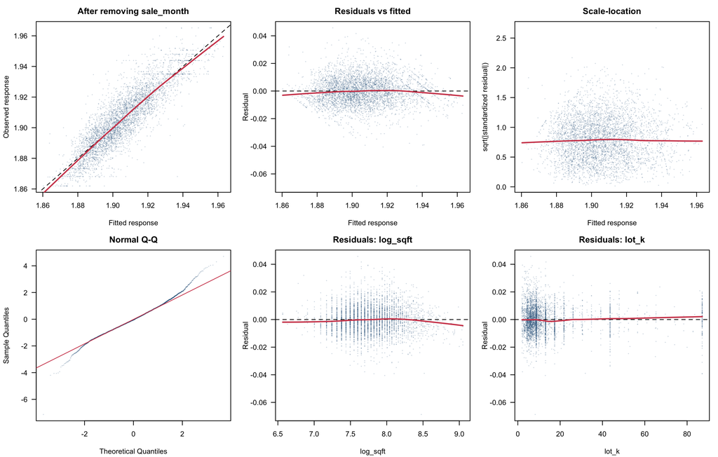

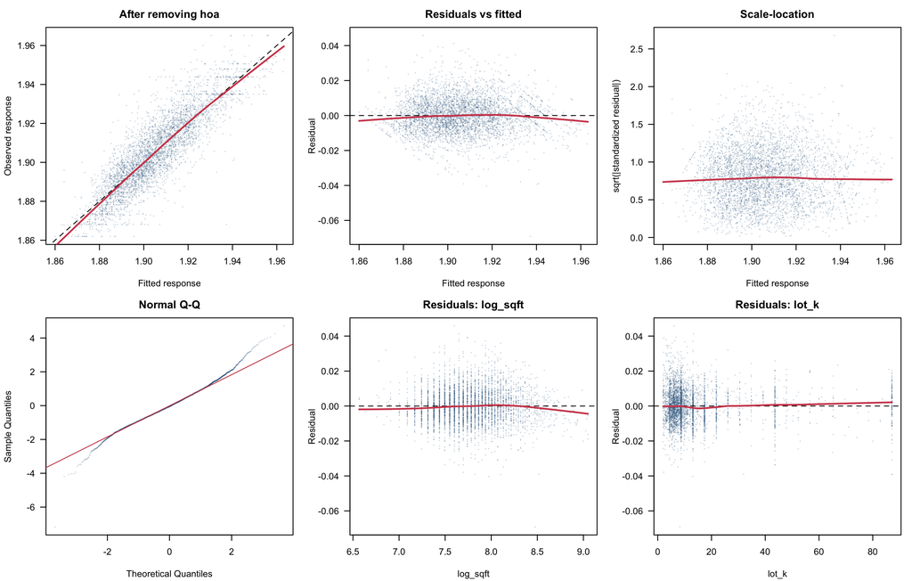

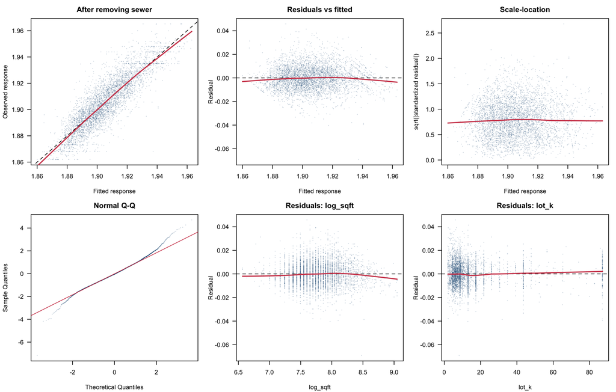

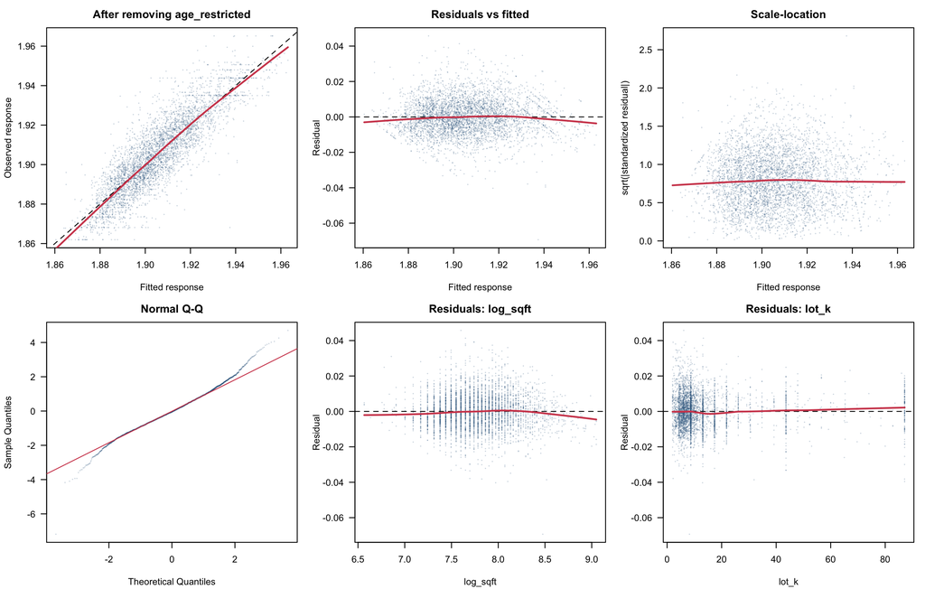

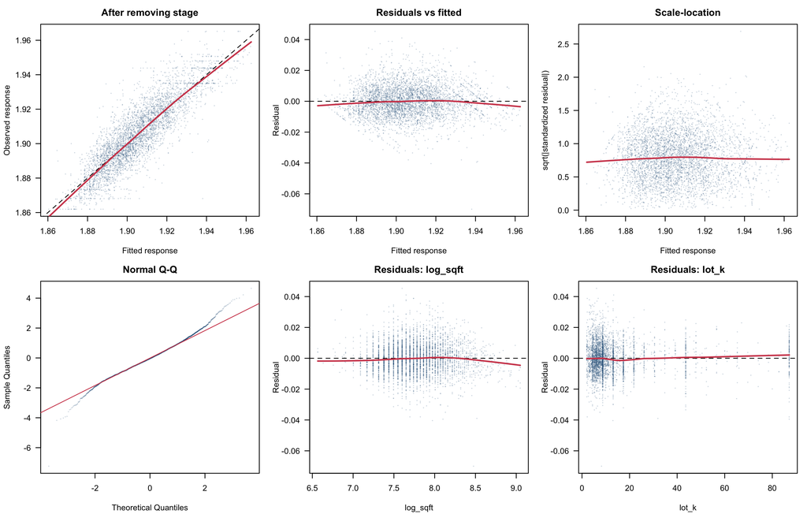

```r
cur <- m_bc_log
for(term in hist_bic$dropped[-1]) {
 cur <- update(cur,as.formula(paste(". ~ . -",term)))
 diagnostic_grid(cur,paste("After removing",term))
}
```

BIC removes sale_month, hoa, sewer, age_restricted, stage. AIC removes sale_month, hoa. We retain the existing BIC specification after reviewing the diagnostic sequence, keeping AIC as a sensitivity comparison.

The stage removal illustrates why BIC is not a 5% significance rule: its nominal partial-F p-value is 3.72e-04, yet removing its two coefficients changes BIC by -0.774. This is a modest BIC preference, not evidence that sale stage has no association. AIC retains stage; the sensitivity table quantifies the resulting change in the focal estimates. We choose BIC for parsimony and disclose this criterion dependence rather than claiming a unique best model.

# 6 Final model and evidence

The final response is `z = 2 - 2/sqrt(price_k)`, with log area by division and the controls below. The eight-coefficient interaction null is equality of the nine area slopes **on this transformed scale**. Coefficients and their ordinary intervals are the primary model summaries. A transformed-price slope is not a constant price elasticity.

For a readable illustration we fix a **hypothetical model-index baseline** of $500,000, rather than estimate an intercept for a chosen house. If `g(P)=2-2/sqrt(P)` and a regional slope is `b`, increasing area by 10% changes the fitted transformed response by `b*log(1.1)`. The price index becomes `g_inverse(g(500)+b*log(1.1))`, where `g_inverse(z)=(1-z/2)^(-2)` for `z<2`. We transform the slope interval monotonically at this fixed reference; baseline estimation uncertainty is not included because the reference is stipulated, not estimated. All intervals are pointwise and ignore selection uncertainty.

This index is the inverse of the fitted mean of transformed price, **not arithmetic mean price**, not automatically the median, and not the former log-model geometric mean. Effects depend on the baseline; tables also show $300,000 and $700,000 references. Covariates stay fixed within each comparison; we do not assert that otherwise identical homes in all divisions have the same baseline price.

```r
ctrl_fin <- "lot_k + stories + bedrooms + fullbath + halfbath + garage + foundation + fireplace + wall + heat_fuel"
f_final <- as.formula(paste("bc_m05 ~ log_sqft * division +",ctrl_fin))
m2<-lm(f_final,data=train)
stopifnot(setequal(attr(terms(m2),"term.labels"),attr(terms(sel_bic),"term.labels")),
 !anyNA(coef(m2)),m2$rank==length(coef(m2)),all(fitted(m2)<2))
m2_noint<-update(m2,.~.-log_sqft:division);m2_noX<-update(m2,.~.-log_sqft:division-log_sqft)
s2<-summary(m2);p2_int_F<-pf_test(m2,m2_noint);p2_X<-pf_test(m2,m2_noX)
p2_int_F
```

```
##            F           df            p          dR2
## 1.667722e+01 8.000000e+00 1.399591e-24 7.748861e-03
```

```r
el<-div_slopes(m2,"log_sqft")
index_change<-function(slope,baseline=500){
 z0<-2-2/sqrt(baseline);z1<-z0+slope*log(1.1)
 stopifnot(all(z1<2))
 100*((1-z1/2)^(-2)/baseline-1)
}
ci2<-confint(m2)
final_coef<-data.frame(term=names(coef(m2)),estimate=coef(m2),se=s2$coefficients[,2],
 lower95=ci2[,1],upper95=ci2[,2],row.names=NULL)
knitr::kable(final_coef,digits=6,caption="Full final inverse-square-root model. Conventional intervals do not account for selection.")
```

Full final inverse-square-root model. Conventional intervals do not account for selection.

| term | estimate | se | lower95 | upper95 |
| --- | --- | --- | --- | --- |
| (Intercept) | 1.657551 | 0.008443 | 1.640997 | 1.674104 |
| log_sqft | 0.031463 | 0.001090 | 0.029327 | 0.033599 |
| divisionNewEngland | 0.118562 | 0.033102 | 0.053666 | 0.183459 |
| divisionMidAtlantic | 0.059496 | 0.018637 | 0.022959 | 0.096033 |
| divisionENCentral | 0.048448 | 0.011872 | 0.025173 | 0.071723 |
| divisionWNCentral | 0.053496 | 0.013764 | 0.026512 | 0.080480 |
| divisionESCentral | -0.011640 | 0.013142 | -0.037406 | 0.014125 |
| divisionWSCentral | -0.053445 | 0.010455 | -0.073942 | -0.032948 |
| divisionMountain | 0.083340 | 0.011674 | 0.060452 | 0.106228 |
| divisionPacific | 0.041470 | 0.014116 | 0.013794 | 0.069145 |
| lot_k | 0.000023 | 0.000010 | 0.000003 | 0.000043 |
| stories2 | -0.001176 | 0.000414 | -0.001987 | -0.000364 |
| stories3plus | 0.005008 | 0.001152 | 0.002749 | 0.007267 |
| bedrooms3 | -0.004866 | 0.000900 | -0.006630 | -0.003102 |
| bedrooms4 | -0.006988 | 0.000953 | -0.008857 | -0.005120 |
| bedrooms5plus | -0.009642 | 0.001096 | -0.011791 | -0.007493 |
| fullbath2 | 0.001420 | 0.001626 | -0.001768 | 0.004607 |
| fullbath3 | 0.006522 | 0.001701 | 0.003187 | 0.009857 |
| fullbath4plus | 0.011917 | 0.001822 | 0.008346 | 0.015489 |
| halfbath1 | 0.002593 | 0.000405 | 0.001800 | 0.003387 |
| halfbath2plus | 0.002453 | 0.001390 | -0.000271 | 0.005178 |
| garage2car | 0.001251 | 0.000844 | -0.000404 | 0.002905 |
| garage3plus | 0.003643 | 0.000948 | 0.001786 | 0.005501 |
| garageother | 0.000135 | 0.001187 | -0.002193 | 0.002463 |
| foundationcrawl | 0.002169 | 0.000660 | 0.000876 | 0.003462 |
| foundationslab | -0.003963 | 0.000504 | -0.004951 | -0.002975 |
| foundationother | -0.001829 | 0.003391 | -0.008478 | 0.004820 |
| fireplace1 | 0.005177 | 0.000385 | 0.004423 | 0.005931 |
| fireplace2plus | 0.004717 | 0.000850 | 0.003049 | 0.006384 |
| wallwood | -0.000494 | 0.000926 | -0.002309 | 0.001320 |
| wallstucco | 0.001158 | 0.000645 | -0.000106 | 0.002422 |
| wallvinyl | -0.001982 | 0.000571 | -0.003101 | -0.000864 |
| wallstone | 0.001748 | 0.001370 | -0.000938 | 0.004434 |
| wallfibercement | 0.000901 | 0.000556 | -0.000190 | 0.001992 |
| wallother | 0.005432 | 0.002674 | 0.000189 | 0.010675 |
| heat_fuelgas | 0.002523 | 0.000397 | 0.001744 | 0.003301 |
| heat_fuelpropane | 0.000671 | 0.001577 | -0.002422 | 0.003764 |
| heat_fuelother | 0.002063 | 0.001509 | -0.000896 | 0.005022 |
| log_sqft:divisionNewEngland | -0.012015 | 0.004125 | -0.020102 | -0.003928 |
| log_sqft:divisionMidAtlantic | -0.006266 | 0.002346 | -0.010866 | -0.001666 |
| log_sqft:divisionENCentral | -0.006144 | 0.001522 | -0.009128 | -0.003159 |
| log_sqft:divisionWNCentral | -0.006993 | 0.001778 | -0.010480 | -0.003507 |
| log_sqft:divisionESCentral | 0.001195 | 0.001693 | -0.002123 | 0.004514 |
| log_sqft:divisionWSCentral | 0.006557 | 0.001342 | 0.003927 | 0.009188 |
| log_sqft:divisionMountain | -0.009109 | 0.001493 | -0.012037 | -0.006182 |
| log_sqft:divisionPacific | -0.003357 | 0.001824 | -0.006932 | 0.000218 |

```r
division_names<-c("South Atlantic","New England","Middle Atlantic","East North Central","West North Central","East South Central","West South Central","Mountain","Pacific")
effects<-data.frame(division=division_names,n=as.vector(table(train$division)[division_levels]),
 transformed_slope=el[,"est"],OLS_low=el[,"lower"],OLS_high=el[,"upper"],
 reference_price_dollars=500000,pct=index_change(el[,"est"]),
 pct_low=index_change(el[,"lower"]),pct_high=index_change(el[,"upper"]))
reference_effects<-do.call(rbind,lapply(c(300,500,700),function(p0)
 data.frame(division=division_names,reference_price_dollars=p0*1000,pct=index_change(el[,"est"],p0))))
write.csv(effects,"results/regional_effects.csv",row.names=FALSE)
write.csv(reference_effects,"results/reference_price_effects.csv",row.names=FALSE)
write.csv(final_coef,"results/final_coefficients.csv",row.names=FALSE)
write.csv(hist_bic,"results/selection_path.csv",row.names=FALSE)
write.csv(hist_aic,"results/selection_path_AIC.csv",row.names=FALSE)
model_comparison<-data.frame(model=c("Full inverse-square-root","AIC selected","BIC selected"),
 coefficients=sapply(list(m_bc_log,sel_aic,m2),function(m)length(coef(m))),
 BIC=sapply(list(m_bc_log,sel_aic,m2),BIC),R2=sapply(list(m_bc_log,sel_aic,m2),r2))
write.csv(model_comparison,"results/model_comparison.csv",row.names=FALSE)
knitr::kable(effects,digits=4,caption="Regional transformed-price slopes and nominal 95% intervals. Percentage illustration uses a fixed $500,000 price index, not mean sale price.")
```

Regional transformed-price slopes and nominal 95% intervals. Percentage illustration uses a fixed $500,000 price index, not mean sale price.

|  | division | n | transformed_slope | OLS_low | OLS_high | reference_price_dollars | pct | pct_low | pct_high |
| --- | --- | --- | --- | --- | --- | --- | --- | --- | --- |
| SouthAtlantic | South Atlantic | 1308 | 0.0315 | 0.0293 | 0.0336 | 5e+05 | 7.0584 | 6.5559 | 7.5644 |
| NewEngland | New England | 39 | 0.0194 | 0.0114 | 0.0275 | 5e+05 | 4.2773 | 2.4757 | 6.1268 |
| MidAtlantic | Middle Atlantic | 119 | 0.0252 | 0.0207 | 0.0297 | 5e+05 | 5.5943 | 4.5668 | 6.6370 |
| ENCentral | East North Central | 510 | 0.0253 | 0.0225 | 0.0281 | 5e+05 | 5.6226 | 4.9788 | 6.2723 |
| WNCentral | West North Central | 313 | 0.0245 | 0.0213 | 0.0277 | 5e+05 | 5.4263 | 4.6894 | 6.1710 |
| ESCentral | East South Central | 344 | 0.0327 | 0.0294 | 0.0359 | 5e+05 | 7.3411 | 6.5819 | 8.1085 |
| WSCentral | West South Central | 850 | 0.0380 | 0.0355 | 0.0405 | 5e+05 | 8.6234 | 8.0203 | 9.2314 |
| Mountain | Mountain | 473 | 0.0224 | 0.0197 | 0.0250 | 5e+05 | 4.9399 | 4.3285 | 5.5566 |
| Pacific | Pacific | 374 | 0.0281 | 0.0247 | 0.0315 | 5e+05 | 6.2703 | 5.4836 | 7.0657 |

```r
knitr::kable(reference_effects,digits=2,caption="The same slope implies different percentage index changes at different reference prices.")
```

The same slope implies different percentage index changes at different reference prices.

|  | division | reference_price_dollars | pct |
| --- | --- | --- | --- |
| SouthAtlantic | South Atlantic | 3e+05 | 5.40 |
| NewEngland | New England | 3e+05 | 3.29 |
| MidAtlantic | Middle Atlantic | 3e+05 | 4.29 |
| ENCentral | East North Central | 3e+05 | 4.31 |
| WNCentral | West North Central | 3e+05 | 4.17 |
| ESCentral | East South Central | 3e+05 | 5.62 |
| WSCentral | West South Central | 3e+05 | 6.58 |
| Mountain | Mountain | 3e+05 | 3.79 |
| Pacific | Pacific | 3e+05 | 4.81 |
| SouthAtlantic1 | South Atlantic | 5e+05 | 7.06 |
| NewEngland1 | New England | 5e+05 | 4.28 |
| MidAtlantic1 | Middle Atlantic | 5e+05 | 5.59 |
| ENCentral1 | East North Central | 5e+05 | 5.62 |
| WNCentral1 | West North Central | 5e+05 | 5.43 |
| ESCentral1 | East South Central | 5e+05 | 7.34 |
| WSCentral1 | West South Central | 5e+05 | 8.62 |
| Mountain1 | Mountain | 5e+05 | 4.94 |
| Pacific1 | Pacific | 5e+05 | 6.27 |
| SouthAtlantic2 | South Atlantic | 7e+05 | 8.43 |
| NewEngland2 | New England | 7e+05 | 5.09 |
| MidAtlantic2 | Middle Atlantic | 7e+05 | 6.67 |
| ENCentral2 | East North Central | 7e+05 | 6.70 |
| WNCentral2 | West North Central | 7e+05 | 6.47 |
| ESCentral2 | East South Central | 7e+05 | 8.77 |
| WSCentral2 | West South Central | 7e+05 | 10.32 |
| Mountain2 | Mountain | 7e+05 | 5.88 |
| Pacific2 | Pacific | 7e+05 | 7.48 |

```r
knitr::kable(model_comparison,digits=4,caption="Same response scale: parsimony versus fit.")
```

Same response scale: parsimony versus fit.

| model | coefficients | BIC | R2 |
| --- | --- | --- | --- |
| Full inverse-square-root | 52 | -27426.06 | 0.7527 |
| AIC selected | 50 | -27439.39 | 0.7525 |
| BIC selected | 46 | -27449.43 | 0.7512 |

## 6.1 Final-model collinearity

```r
m2_centered<-lm(update(f_final,.~.-log_sqft*division+log_sqft_c*division),data=train)
centering_max_fit_diff<-max(abs(fitted(m2)-fitted(m2_centered)))
stopifnot(centering_max_fit_diff<1e-10)
final_vif<-rbind(column_vif(m2,"original"),column_vif(m2_centered,"centered_log_area"))
write.csv(final_vif,"results/final_column_VIF.csv",row.names=FALSE)
knitr::kable(final_vif,digits=3,caption="Complete final-model VIFs: ordinary auxiliary regressions for all encoded columns, before and after centering.")
```

Complete final-model VIFs: ordinary auxiliary regressions for all encoded columns, before and after centering.

| parameterization | column | VIF |
| --- | --- | --- |
| original | log_sqft | 6.695 |
| original | divisionNewEngland | 443.912 |
| original | divisionMidAtlantic | 421.338 |
| original | divisionENCentral | 664.724 |
| original | divisionWNCentral | 576.610 |
| original | divisionESCentral | 573.335 |
| original | divisionWSCentral | 782.714 |
| original | divisionMountain | 601.926 |
| original | divisionPacific | 713.745 |
| original | lot_k | 1.307 |
| original | stories2 | 1.943 |
| original | stories3plus | 1.280 |
| original | bedrooms3 | 8.897 |
| original | bedrooms4 | 9.974 |
| original | bedrooms5plus | 6.682 |
| original | fullbath2 | 28.401 |
| original | fullbath3 | 26.355 |
| original | fullbath4plus | 13.111 |
| original | halfbath1 | 1.830 |
| original | halfbath2plus | 1.198 |
| original | garage2car | 6.496 |
| original | garage3plus | 6.814 |
| original | garageother | 1.850 |
| original | foundationcrawl | 1.667 |
| original | foundationslab | 2.526 |
| original | foundationother | 1.083 |
| original | fireplace1 | 1.459 |
| original | fireplace2plus | 1.210 |
| original | wallwood | 1.459 |
| original | wallstucco | 3.121 |

[output cut: 60 more lines]

Centering changes the reference size for division intercepts, with a maximum fitted-value difference of 2.8e-14; it does not improve fit or remove substantive dependence among housing characteristics. The numerical log-area column still has VIF 6.69. Area shares information with room counts and other features. We retain the research variable and report its uncertainty rather than remove it to satisfy a threshold. The largest centered encoded-column VIF is 28.40 (for fullbath2). Some bathroom-category indicators remain strongly redundant with other columns. Dummy-variable reference coding and correlations among housing features both affect these column diagnostics. We do not claim that centering eliminates collinearity; coefficients for individual controls can be poorly determined. Full rank rules out exact aliasing but not imprecision. The focal area estimate is conditional on these correlated controls, another reason to avoid a causal or overprecise interpretation.

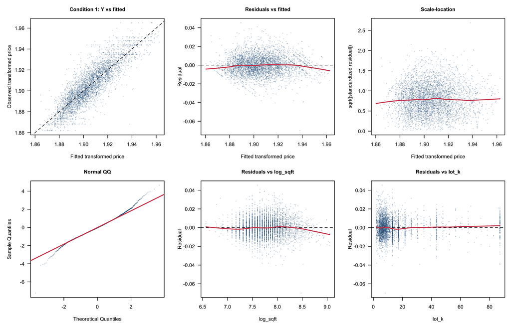

```r
e2 <- resid(m2); yhat2 <- fitted(m2); r2s <- rstandard(m2)
draw_final <- function() {
  par(mfrow = c(2, 3), mar = c(4.5, 5, 3, 1), las = 1)
  plot(yhat2, train$bc_m05, pch = 16, cex = 0.4, col = pt_col, xlab = "Fitted transformed price",
       ylab = "Observed transformed price", main = "Condition 1: Y vs fitted", cex.main = 1)
  abline(0, 1, lty = 2); lines(lowess(yhat2, train$log_price, f = 0.3), col = ln_col, lwd = 2)
  plot(yhat2, e2, pch = 16, cex = 0.4, col = pt_col, xlab = "Fitted transformed price", ylab = "Residual",
       main = "Residuals vs fitted", cex.main = 1)
  abline(h = 0, lty = 2); lines(lowess(yhat2, e2, f = 0.3), col = ln_col, lwd = 2)
  plot(yhat2, sqrt(abs(r2s)), pch = 16, cex = 0.4, col = pt_col, xlab = "Fitted transformed price",
       ylab = "sqrt(|standardized residual|)", main = "Scale-location", cex.main = 1)
  lines(lowess(yhat2, sqrt(abs(r2s)), f = 0.3), col = ln_col, lwd = 2)
  qqnorm(r2s, pch = 16, cex = 0.4, col = pt_col, main = "Normal QQ", cex.main = 1)
  qqline(r2s, col = ln_col, lwd = 2)
  for (v in c("log_sqft", "lot_k")) {
    plot(train[[v]], e2, pch = 16, cex = 0.4, col = pt_col, xlab = v, ylab = "Residual",
         main = paste("Residuals vs", v), cex.main = 1)
    abline(h = 0, lty = 2); lines(lowess(train[[v]], e2, f = 0.3), col = ln_col, lwd = 2)
  }
}
fig_out("part2_final_residuals.png", 12, 7.6, draw_final)
```

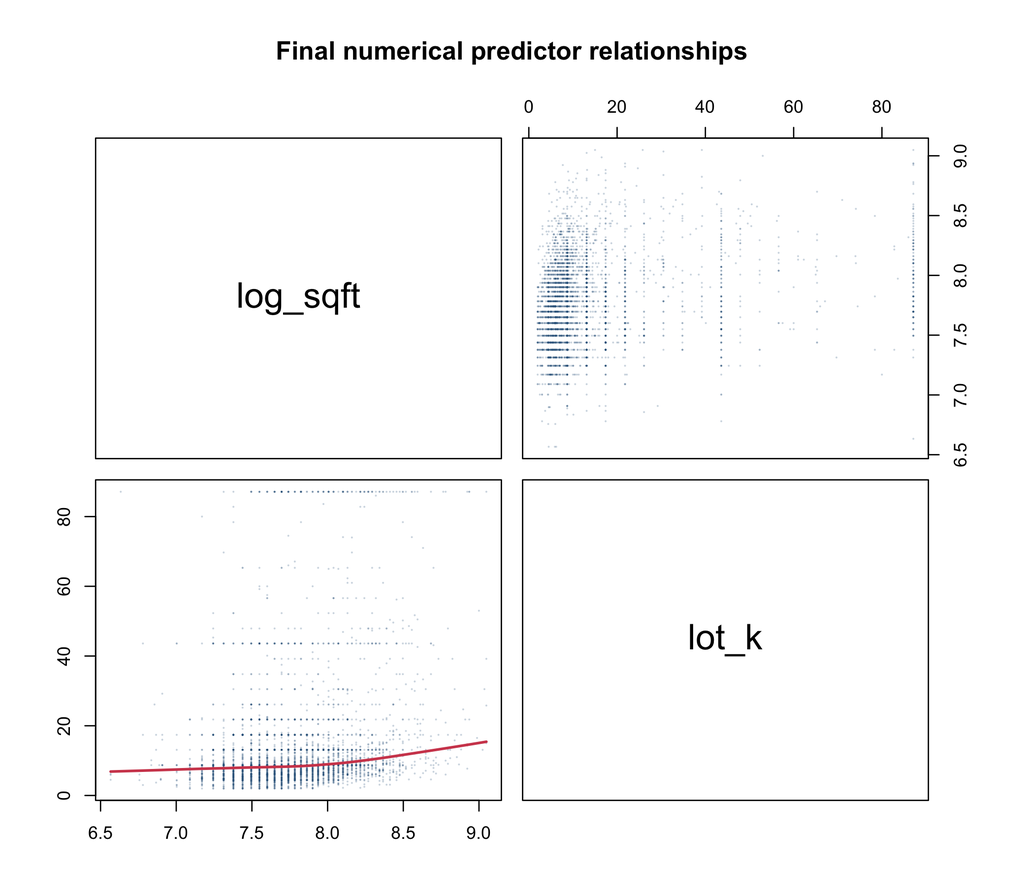

```r
predictor_grid(m2,"Final numerical predictor relationships")
```

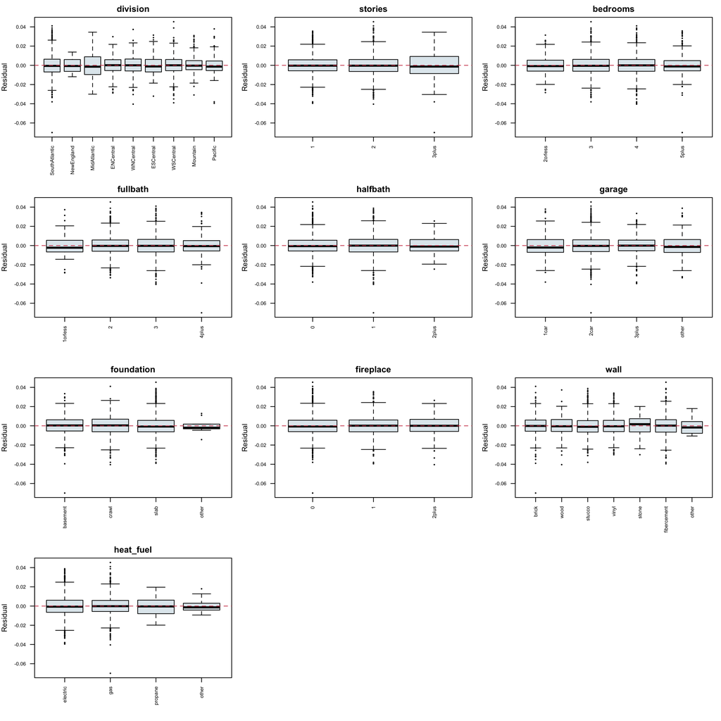

```r
category_grid(m2,"Final categorical residuals")
```

The observed-versus-fitted and residual smoothers are approximately linear/flat over the main training range after the inverse-square-root/log transformation. The scale-location trend is much flatter than in the raw-price or log-price models, but no graph establishes perfectly constant variance. Category residual panels are retained to inspect group-specific spread. The predictor pair plots are only a limited screen, not proof of all conditional relationships. Normal Q-Q tails still deviate; independence is unverified because fine geographic/builder identifiers are unavailable. Selection and transformation choice also use these training data. Consequently the ordinary p-values are exploratory, not calibrated confirmation, and nominal intervals may misstate uncertainty.

# 7 Influence and targeted sensitivity

Influence thresholds flag records for investigation, not automatic deletion. We retain observations without documented errors, record the most influential IDs, and refit after removing each of the ten largest Cook distances one at a time. These are sensitivity checks; the full-data model remains primary.

```r
infl_table <- function(m, focal) {
  N <- nobs(m); p <- length(coef(m))
  h <- hatvalues(m); r <- rstandard(m); cd <- cooks.distance(m); dff <- dffits(m)
  dfb <- dfbetas(m)[, focal, drop = FALSE]
  base <- data.frame(
    measure = c("leverage h_ii", "|standardized residual|", "Cook's D", "Cook's D", "|DFFITS|"),
    cutoff_rule = c("2p/n", "4", "4/n", "F(0.5; p, n-p)", "2*sqrt(p/n)"),
    cutoff = c(2 * p / N, 4, 4 / N, qf(0.5, p, N - p), 2 * sqrt(p / N)),
    n_beyond = c(sum(h > 2 * p / N), sum(abs(r) > 4), sum(cd > 4 / N), sum(cd > qf(0.5, p, N - p)),
                 sum(abs(dff) > 2 * sqrt(p / N))),
    max_value = c(max(h), max(abs(r)), max(cd), max(cd), max(abs(dff))))
  fb <- data.frame(measure = paste("|DFBETAS|", focal), cutoff_rule = "2/sqrt(n)",
                   cutoff = 2 / sqrt(N), n_beyond = colSums(abs(dfb) > 2 / sqrt(N)),
                   max_value = apply(abs(dfb), 2, max), row.names = NULL)
  rbind(base, fb)
}
focal1 <- c("sqft100", paste0("sqft100:division", division_levels[-1]))
focal2 <- c("log_sqft", paste0("log_sqft:division", division_levels[-1]))
infl1 <- infl_table(m1, focal1); infl2 <- infl_table(m2, focal2)
knitr::kable(infl1, digits = 4, caption = "Influence screening: initial and final models, respectively")
```

Influence screening: initial and final models, respectively

| measure | cutoff_rule | cutoff | n_beyond | max_value |
| --- | --- | --- | --- | --- |
| leverage h_ii | 2p/n | 0.0240 | 349 | 0.3638 |
| \|standardized residual\| | 4 | 4.0000 | 36 | 12.0557 |
| Cook’s D | 4/n | 0.0009 | 313 | 0.1845 |
| Cook’s D | F(0.5; p, n-p) | 0.9874 | 0 | 0.1845 |
| \|DFFITS\| | 2*sqrt(p/n) | 0.2192 | 313 | 3.1167 |
| \|DFBETAS\| sqft100 | 2/sqrt(n) | 0.0304 | 239 | 0.2748 |
| \|DFBETAS\| sqft100:divisionNewEngland | 2/sqrt(n) | 0.0304 | 64 | 2.2658 |
| \|DFBETAS\| sqft100:divisionMidAtlantic | 2/sqrt(n) | 0.0304 | 124 | 2.6320 |
| \|DFBETAS\| sqft100:divisionENCentral | 2/sqrt(n) | 0.0304 | 161 | 0.5940 |
| \|DFBETAS\| sqft100:divisionWNCentral | 2/sqrt(n) | 0.0304 | 136 | 0.3849 |
| \|DFBETAS\| sqft100:divisionESCentral | 2/sqrt(n) | 0.0304 | 137 | 0.3821 |
| \|DFBETAS\| sqft100:divisionWSCentral | 2/sqrt(n) | 0.0304 | 172 | 0.2602 |
| \|DFBETAS\| sqft100:divisionMountain | 2/sqrt(n) | 0.0304 | 181 | 0.5887 |
| \|DFBETAS\| sqft100:divisionPacific | 2/sqrt(n) | 0.0304 | 141 | 0.3481 |

```r
knitr::kable(infl2, digits = 4, caption = "Influence screening: initial and final models, respectively")
```

Influence screening: initial and final models, respectively

| measure | cutoff_rule | cutoff | n_beyond | max_value |
| --- | --- | --- | --- | --- |
| leverage h_ii | 2p/n | 0.0212 | 414 | 0.1991 |
| \|standardized residual\| | 4 | 4.0000 | 7 | 7.2381 |
| Cook’s D | 4/n | 0.0009 | 250 | 0.0240 |
| Cook’s D | F(0.5; p, n-p) | 0.9857 | 0 | 0.0240 |
| \|DFFITS\| | 2*sqrt(p/n) | 0.2061 | 251 | 1.0567 |
| \|DFBETAS\| log_sqft | 2/sqrt(n) | 0.0304 | 261 | 0.2145 |
| \|DFBETAS\| log_sqft:divisionNewEngland | 2/sqrt(n) | 0.0304 | 49 | 0.4676 |
| \|DFBETAS\| log_sqft:divisionMidAtlantic | 2/sqrt(n) | 0.0304 | 94 | 0.4215 |
| \|DFBETAS\| log_sqft:divisionENCentral | 2/sqrt(n) | 0.0304 | 199 | 0.2673 |
| \|DFBETAS\| log_sqft:divisionWNCentral | 2/sqrt(n) | 0.0304 | 180 | 0.2205 |
| \|DFBETAS\| log_sqft:divisionESCentral | 2/sqrt(n) | 0.0304 | 154 | 0.3585 |
| \|DFBETAS\| log_sqft:divisionWSCentral | 2/sqrt(n) | 0.0304 | 230 | 0.2347 |
| \|DFBETAS\| log_sqft:divisionMountain | 2/sqrt(n) | 0.0304 | 195 | 0.2134 |
| \|DFBETAS\| log_sqft:divisionPacific | 2/sqrt(n) | 0.0304 | 144 | 0.2373 |

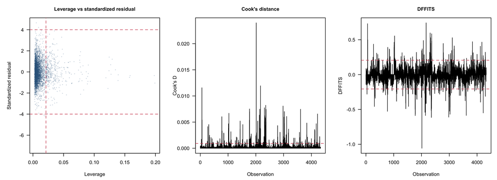

```r
draw_infl <- function() {
  N <- nobs(m2); p <- length(coef(m2))
  par(mfrow = c(1, 3), mar = c(4.5, 5, 3, 1), las = 1)
  plot(hatvalues(m2), rstandard(m2), pch = 16, cex = 0.4, col = pt_col, xlab = "Leverage",
       ylab = "Standardized residual", main = "Leverage vs standardized residual", cex.main = 1)
  abline(v = 2 * p / N, h = c(-4, 4), lty = 2, col = ln_col)
  plot(cooks.distance(m2), type = "h", xlab = "Observation", ylab = "Cook's D",
       main = "Cook's distance", cex.main = 1)
  abline(h = 4 / N, lty = 2, col = ln_col)
  plot(dffits(m2), type = "h", xlab = "Observation", ylab = "DFFITS", main = "DFFITS", cex.main = 1)
  abline(h = c(-1, 1) * 2 * sqrt(p / N), lty = 2, col = ln_col)
}
fig_out("part2_final_influence.png", 12, 4, draw_infl)
```

```r
top <- head(order(cooks.distance(m2),decreasing=TRUE),10)
influence_cases <- data.frame(id=train$id[top],cooks_D=cooks.distance(m2)[top],
 leverage=hatvalues(m2)[top],standardized_residual=rstandard(m2)[top],
 price_flag=train$slpr_flag[top],sqft_flag=train$sqft_flag[top],lot_flag=train$lot_flag[top])
leave_one <- do.call(rbind,lapply(top,function(i){
 mm<-lm(f_final,data=train[-i,]); es<-div_slopes(mm,"log_sqft")
 data.frame(removed_id=train$id[i],max_abs_slope_change=max(abs(es[,"est"]-el[,"est"])),
 max_abs_index_pctpoint_change=max(abs(index_change(es[,"est"])-index_change(el[,"est"]))),
 interaction_F_p=pf_test(mm,update(mm,.~.-log_sqft:division))["p"])
}))
write.csv(influence_cases,"results/influential_records.csv",row.names=FALSE)
write.csv(leave_one,"results/influence_sensitivity.csv",row.names=FALSE)
knitr::kable(influence_cases,digits=4,caption="Table 5. Ten largest Cook distances and disclosure flags.")
```

Table 5. Ten largest Cook distances and disclosure flags.

|  | id | cooks_D | leverage | standardized_residual | price_flag | sqft_flag | lot_flag |
| --- | --- | --- | --- | --- | --- | --- | --- |
| 2794 | 11303 | 0.0240 | 0.0206 | -7.2381 | 1 | 0 | 0 |
| 2998 | 12533 | 0.0119 | 0.0350 | 3.8899 | 0 | 0 | 0 |
| 82 | 146 | 0.0116 | 0.0468 | 3.2926 | 0 | 0 | 0 |
| 3272 | 14325 | 0.0082 | 0.0778 | -2.1180 | 1 | 0 | 0 |
| 4195 | 17279 | 0.0081 | 0.0234 | -3.9374 | 0 | 0 | 0 |
| 3215 | 13610 | 0.0077 | 0.0271 | 3.5777 | 0 | 0 | 0 |
| 2469 | 9922 | 0.0075 | 0.0390 | -2.9191 | 1 | 0 | 0 |
| 2965 | 12396 | 0.0075 | 0.0193 | -4.1777 | 0 | 0 | 0 |
| 5155 | 20933 | 0.0075 | 0.1225 | -1.5686 | 0 | 0 | 0 |
| 3291 | 14453 | 0.0074 | 0.0339 | 3.1208 | 0 | 0 | 0 |

```r
knitr::kable(leave_one,digits=5,caption="Table 6. One-at-a-time deletion sensitivity, not a new selected model.")
```

Table 6. One-at-a-time deletion sensitivity, not a new selected model.

|  | removed_id | max_abs_slope_change | max_abs_index_pctpoint_change | interaction_F_p |
| --- | --- | --- | --- | --- |
| p | 11303 | 0.00036 | 0.08097 | 0 |
| p1 | 12533 | 0.00015 | 0.03572 | 0 |
| p2 | 146 | 0.00061 | 0.14516 | 0 |
| p3 | 14325 | 0.00080 | 0.18556 | 0 |
| p4 | 17279 | 0.00016 | 0.03601 | 0 |
| p5 | 13610 | 0.00030 | 0.06753 | 0 |
| p6 | 9922 | 0.00017 | 0.03879 | 0 |
| p7 | 12396 | 0.00026 | 0.05964 | 0 |
| p8 | 20933 | 0.00030 | 0.06763 | 0 |
| p9 | 14453 | 0.00075 | 0.17328 | 0 |

```r
sens_models <- list(full_inverse_sqrt=m_bc_log,AIC=sel_aic,
 no_price_coding=lm(f_final,data=train[train$slpr_flag==0,]),
 no_price_area_lot_coding=lm(f_final,data=train[train$slpr_flag==0 & train$sqft_flag==0 & train$lot_flag==0,]))
sensitivity <- do.call(rbind,lapply(names(sens_models),function(nm){
 mm<-sens_models[[nm]]; es<-div_slopes(mm,"log_sqft")
 data.frame(model=nm,n=nobs(mm),interaction_F_p=pf_test(mm,update(mm,.~.-log_sqft:division))["p"],
 max_abs_slope_change=max(abs(es[,"est"]-el[,"est"])),
 max_abs_index_pctpoint_change=max(abs(index_change(es[,"est"])-index_change(el[,"est"]))))
}))
write.csv(sensitivity,"results/sensitivity.csv",row.names=FALSE)
sensitivity_slopes <- data.frame(division=division_names, baseline=el[,"est"],sapply(sens_models,function(mm) div_slopes(mm,"log_sqft")[,"est"]))
write.csv(sensitivity_slopes,"results/sensitivity_slopes.csv",row.names=FALSE)
knitr::kable(sensitivity,digits=5,caption="Table 7. Targeted coefficient sensitivity checks; F p-values retain the same assumption limitations.")
```

Table 7. Targeted coefficient sensitivity checks; F p-values retain the same assumption limitations.

|  | model | n | interaction_F_p | max_abs_slope_change | max_abs_index_pctpoint_change |
| --- | --- | --- | --- | --- | --- |
| p | full_inverse_sqrt | 4330 | 0 | 0.00089 | 0.20453 |
| p1 | AIC | 4330 | 0 | 0.00077 | 0.17649 |
| p2 | no_price_coding | 4022 | 0 | 0.00546 | 1.25198 |
| p3 | no_price_area_lot_coding | 3906 | 0 | 0.00868 | 1.99765 |

Removing each of the ten largest Cook-distance observations one at a time changes the $500,000 reference percentage-index contrast by at most 0.19 percentage points. Excluding jointly flagged price/area/lot observations changes it by as much as 2.00 percentage points. We report changes in magnitude, not just whether p-values remain small. Exclusions change the population analysed and do not undo disclosure coding; no flagged observations are automatically removed from the primary model.

For response-scale sensitivity, the previous log-price model gives constant percentage geometric-mean contrasts. It answers a different transformed-mean question, so its slopes should not be directly subtracted from the new slopes. We place the new fixed-reference index contrasts beside those older log-model contrasts only to show how an apparently simple regional ranking depends on the estimand.

```r
old_log_model<-lm(update(f_final,log_price~.),data=train)
old_log_slopes<-div_slopes(old_log_model,"log_sqft")
scale_comparison<-data.frame(division=division_names,
 inverse_sqrt_index_pct_at_500k=effects$pct,
 log_model_geometric_mean_pct=100*(1.1^old_log_slopes[,"est"]-1))
write.csv(scale_comparison,"results/response_scale_sensitivity.csv",row.names=FALSE)
knitr::kable(scale_comparison,digits=2,caption="Different response-scale estimands; these are not interchangeable estimates of arithmetic mean price.")
```

Different response-scale estimands; these are not interchangeable estimates of arithmetic mean price.

|  | division | inverse_sqrt_index_pct_at_500k | log_model_geometric_mean_pct |
| --- | --- | --- | --- |
| SouthAtlantic | South Atlantic | 7.06 | 6.68 |
| NewEngland | New England | 4.28 | 6.20 |
| MidAtlantic | Middle Atlantic | 5.59 | 7.26 |
| ENCentral | East North Central | 5.62 | 5.13 |
| WNCentral | West North Central | 5.43 | 5.23 |
| ESCentral | East South Central | 7.34 | 6.92 |
| WSCentral | West South Central | 8.62 | 7.24 |
| Mountain | Mountain | 4.94 | 5.73 |
| Pacific | Pacific | 6.27 | 7.18 |

# 8 Frozen model and optional test evaluation

The current inverse-square-root specification is saved before any test evaluation. The earlier log-model review freeze is superseded without using held-out outcomes. Predictions use training estimates unchanged; no model is fitted or selected on the test sample. The optional evaluation below scores the transformed response. Its RMSE cannot be compared numerically with a previous log-scale RMSE. Back-transformed indices are not claimed as arithmetic-mean price predictions.

```r
freeze <- list(formula=paste(deparse(f_final,width.cutoff=500),collapse=" "),
 coefficients=coef(m2),train_ids=train$id,split_md5=unname(tools::md5sum("data/split_ids.csv")),
 raw_md5=unname(tools::md5sum("data/original/soc25.csv")))
saveRDS(freeze,"results/frozen_specification.rds")
jsonlite::write_json(freeze,"results/frozen_specification.json",pretty=TRUE,auto_unbox=TRUE)
```

```r
if(isTRUE(params$evaluate_test)) {
 all_data<-read.csv("data/cleaned/soc_clean_review.csv")
 test<-as_model_factors(all_data[all_data$split=="test",]);rm(all_data)
 test$bc_m05 <- -2*(test$price_k^(-.5)-1);test$log_sqft<-log(test$sqft100*100)
 stopifnot(nrow(test)==1855, !any(test$id %in% train$id))
 pred<-predict(m2,newdata=test)
 stopifnot(all(is.finite(pred)))
 test_metrics<-data.frame(n=nrow(test),RMSE_transformed=sqrt(mean((test$bc_m05-pred)^2)),
 MAE_transformed=mean(abs(test$bc_m05-pred)),
 R2_test=1-sum((test$bc_m05-pred)^2)/sum((test$bc_m05-mean(test$bc_m05))^2))
 write.csv(test_metrics,"results/test_metrics.csv",row.names=FALSE)
 knitr::kable(test_metrics,digits=4,caption="Table 9. Fixed-model test predictions; no refitting.")
} else cat("Test evaluation disabled. Training results are not held-out performance.")
```

```
## Test evaluation disabled. Training results are not held-out performance.
```

# 9 Conclusion and limitations

The fitted transformed-price slopes are positive in all nine divisions. For a fixed hypothetical $500,000 model-index baseline, 10% more area corresponds to fitted index changes from 4.3% to 8.6%. This is a conditional illustration, not a constant elasticity or an arithmetic-mean price effect. The eight-coefficient interaction comparison gives F(8,4284)= 16.68, nominal p=1.40e-24, and adds 0.0077 to training R-squared on the transformed scale. Automated selection invalidates ordinary confirmatory interpretation (Module 9, slide 48); unverified independence, residual tail deviations and other selection steps compound that limitation.

The estimated variation is qualitatively consistent with Sirmans et al. (2006), while construction-cost mechanisms and quantile-specific patterns in the other studies remain untested. Interpretation and regional ordering change with response scale. New England has only 39 training observations. Complete-case selection, disclosure coding and missing fine location/builder identifiers limit population generalization. A future study should use those identifiers and survey-design information, then assess an agreed specification on new data. No held-out performance is claimed here.

# 10 References

Gyourko, J., & Saiz, A. (2006). Construction costs and the supply of housing structure. *Journal of Regional Science, 46*(4), 661-680. https://doi.org/10.1111/j.1467-9787.2006.00472.x

Sirmans, G. S., MacDonald, L., Macpherson, D. A., & Zietz, E. N. (2006). The value of housing characteristics: A meta analysis. *The Journal of Real Estate Finance and Economics, 33*, 215-240. https://doi.org/10.1007/s11146-006-9983-5

Zietz, J., Sirmans, G. S., & Smersh, G. (2008). The impact of inflation on home prices and the valuation of housing characteristics across the price distribution. *Journal of Housing Research, 17*(2), 119-137. https://doi.org/10.1080/10835547.2008.12091992

U.S. Census Bureau. (2026). *Survey of Construction microdata: 2025 file*. https://www.census.gov/construction/chars/microdata.html

U.S. Census Bureau. (n.d.). *Survey of Construction microdata files: Variable guide*. Included with the data package.

# 11 Reproducibility record

```r
for(nm in c("raw","log","final")){
 mm<-switch(nm,raw=m1,log=old_log_model,final=m2)
 write.csv(data.frame(fitted=fitted(mm),standardized=rstandard(mm)),paste0("figures/poster_",nm,"_data.csv"),row.names=FALSE)
 sm<-lowess(fitted(mm),sqrt(abs(rstandard(mm))))
 write.csv(data.frame(x=sm$x,y=sm$y),paste0("figures/poster_",nm,"_smoother.csv"),row.names=FALSE)
}
png("figures/poster_diagnostics.png",width=1800,height=1300,res=180)
par(mfrow=c(2,2),mar=c(4,4,2,1),las=1)
for(mm in list(m1,m2)){
 plot(fitted(mm),sqrt(abs(rstandard(mm))),pch=16,cex=.3,col=pt_col,xlab="Fitted response",ylab="sqrt(|standardized residual|)")
 lines(lowess(fitted(mm),sqrt(abs(rstandard(mm)))),col=ln_col,lwd=2)
 qqnorm(rstandard(mm),pch=16,cex=.3,col=pt_col);qqline(rstandard(mm),col=ln_col,lwd=2)
};dev.off()
```

```r
diagnostic_models<-list(raw_price=m1,previous_log_price=old_log_model,final_inverse_sqrt=m2)
diagnostic_numbers<-do.call(rbind,lapply(names(diagnostic_models),function(nm){
 mm<-diagnostic_models[[nm]];rr<-rstandard(mm);ss<-spread_summary(mm)
 data.frame(model=nm,R2=r2(mm),adjR2=adjr2(mm),std_residual_skew=skew(rr),
 std_residual_excess_kurtosis=exkurt(rr),max_Cook=max(cooks.distance(mm)),spread_ratio=ss["ratio"])
}))
write.csv(diagnostic_numbers,"results/diagnostic_numbers.csv",row.names=FALSE)
summary_numbers<-list(revision=2,response="2-2/sqrt(price_k)",n_train=n,coefficient_count=length(coef(m2)),
 F=as.list(p2_int_F),lambda_original=lambda_exact,lambda_original_ci=lambda_ci,
 lambda_log_area=lambda_log,lambda_log_area_ci=lambda_log_ci,
 train_RMSE_transformed=sqrt(mean(resid(m2)^2)),reference_price_dollars=500000,
 min_index_pct=min(effects$pct),max_index_pct=max(effects$pct),
 max_leave_one_pctpoint_change=max(leave_one$max_abs_index_pctpoint_change),
 max_flags_pctpoint_change=sensitivity$max_abs_index_pctpoint_change[sensitivity$model=="no_price_area_lot_coding"],
 centering_max_fit_diff=centering_max_fit_diff,test_evaluated=isTRUE(params$evaluate_test))
jsonlite::write_json(summary_numbers,"results/summary.json",pretty=TRUE,auto_unbox=TRUE,digits=12)
saveRDS(list(model=m2,train=train,raw_model=m1,old_log_model=old_log_model,full_model=m_bc_log),"results/review_models.rds")
```